# Lyme Disease Ticks

Janis Corona

8/26/2020

This data analysis is on lyme disease using GEO series data made readily available in its normalized state from GSE145974 on ncbi.nlm.nih.gov as the accession number. The data is from the [platform GPL13667](https://www.ncbi.nlm.nih.gov/geo/query/acc.cgi?acc=GPL13667) and the [series data](https://ftp.ncbi.nlm.nih.gov/geo/series/GSE145nnn/GSE145974/matrix/). There are also some CEL/TAR files for Ubuntu but I couldn’t get my ubuntu machines to recognize it, and the instructions and tutorials for accessing the SRAtoolkit and using the Windows Ubuntu app, didn’t avail, so I am using the text files only.If you have a windows 10 tutorial on running SRAtoolkit using the ubuntu app for windows or getting the cel files to work on ubuntu with a VirtualBox disk image of ubuntu that works because you tried it within 24 hours and it worked exactly as explained, please share. I have yet to get those up and running. Possibly the new updates to virtualBox or my other apps, like docker or MongoDB or Tableau are interfering. I am not going to waste time figuring it out, its a time trap.

All the data was there as far as being filled out with values for the feature names, because I do recall exploring some platforms and series downloadable text files and only the header information was there and none of the values. The method used for processing was expression profiling by microarray on peripheral blood mononucleated cells (PBMC). The values seem to be scaled or normalized already as the values are inclusive of negative values.

There is a research article available from the researchers on this study to accompany the data for free through [pubMed](https://www.ncbi.nlm.nih.gov/pmc/articles/PMC7078463/pdf/mBio.00047-20.pdf):

“Global Transcriptome Analysis Identifies a Diagnostic Signature for Early Disseminated Lyme Disease and Its Resolution” authored by the following researchers: Mary M. Petzke,a Konstantin Volyanskyy,b Yong Mao,b Byron Arevalo,a Raphael Zohn,a Johanna Quituisaca,a Gary P. Wormser,c Nevenka Dimitrova,b Ira Schwartza

They are with the Department of Microbiology and Immunology, School of Medicine, New York Medical College, Valhalla, New York, USA bPhillips Research North America, Valhalla, New York, USA Division of Infectious Diseases, Department of Medicine, New York Medical College, Valhalla, New York, USA **Citation** Petzke MM, Volyanskyy K, Mao Y, Arevalo B, Zohn R, Quituisaca J, Wormser GP, Dimitrova N, Schwartz I. 2020. Global transcriptome analysis identifies a diagnostic signature for early disseminated Lyme disease and its resolution. mBio 11:e00047-20. https:// doi.org/10.1128/mBio.00047-20. Editor Steven J. Norris, McGovern Medical School Copyright © 2020 Petzke et al. This is an openaccess article distributed under the terms of the Creative Commons Attribution 4.0 International license. Address correspondence to Mary M. Petzke, mpetzke@nymc.edu. This article is a direct contribution from Ira Schwartz, a Fellow of the American Academy of Microbiology, who arranged for and secured reviews by Patricia Rosa, NIAID, NIH, and John Leong, Tufts University School of Medicine. Received 9 January 2020 Accepted 31 January 2020 **Published 17 March 2020** “**ABSTRACT** A bioinformatics approach was employed to identify transcriptome alterations in the peripheral blood mononuclear cells of well-characterized human subjects who were diagnosed with early disseminated Lyme disease (LD) based on stringent microbiological and clinical criteria. Transcriptomes were assessed at the time of presentation and also at approximately 1 month (early convalescence) and 6 months (late convalescence) after initiation of an appropriate antibiotic regimen. Comparative transcriptomics identified 335 transcripts, representing 233 unique genes, with significant alterations of at least 2-fold expression in acute- or convalescent-phase blood samples from LD subjects relative to healthy donors. Acute-phase blood samples from LD subjects had the largest number of differentially expressed transcripts (187 induced, 54 repressed). This transcriptional profile, which was dominated by interferon-regulated genes, was sustained during early convalescence. 6 months after antibiotic treatment the transcriptome of LD subjects was indistinguishable from that of healthy controls based on two separate methods of analysis. Return of the LD expression profile to levels found in control subjects was concordant with disease outcome; 82% of subjects with LD experienced at least one symptom at the baseline visit compared to 43% at the early convalescence time point and only a single patient (9%) at the 6-month convalescence time point. Using the random forest machine learning algorithm, we developed an efficient computational framework to identify sets of 20 classifier genes that discriminated LD from other bacterial and viral infections. These novel LD biomarkers not only differentiated subjects with acute disseminated LD from healthy controls with 96% accuracy but also distinguished between subjects with acute and resolved (late convalescent) disease with 97% accuracy. IMPORTANCE Lyme disease (LD), caused by Borrelia burgdorferi, is the most common tick-borne infectious disease in the United States. We examined gene expression patterns in the blood of individuals with early disseminated LD at the time of diagnosis (acute) and also at approximately 1 month and 6 months following antibiotic treatment. A distinct acute LD profile was observed that was sustained during early convalescence (1 month) but returned to control levels 6 months after treatment. Using a computer learning algorithm, we identified sets of 20 classifier genes that discriminate LD from other bacterial and viral infections. In addition, these novel LD biomarkers are highly accurate in distinguishing patients with acute LD from healthy subjects and in discriminating between individuals with active and resolved infection. This computational approach offers the potential for more accurate diagnosis of early disseminated Lyme disease. It may also allow improved monitoring of treatment efficacy and disease resolution.” ***

The study authors used the same algorithms I always go to for analysis and scored well, random forest. It tends to always perform better in classification. But sometimes other algorithms perform better. Data scientists are suggested to not use just one type for all data as not all data is the same, but also some are almost as good and take much less time, depending on how many trees your algorithm is tuned to. I do want to see if these genes can be discovered that are similar to the genes they discovered and use them to predict samples from other studies, but this data is already normalized, and the method that was used was not given, so the first part of this study is an attempt at bringing back the original raw values. This is RNA blood samples, PBMC, and I do have some COVID-19 samples that are also peripheral Blood mononucleated cells type tissue, but the processing was high throughput expression profiling and not microarray. So, I would be able to split this data and see if it can predict the samples on unseen data of the testing set instead.

```r
library(MASS)
library(dplyr)
library(tidyr)

library(e1071)
library(caret)
library(randomForest)
library(MASS)
#library(gbm)
library(RANN) #used in the tuning parameter of rf method of caret for 'oob' one out bag
ticks <- read.delim('GSE145974_series_matrix.txt',sep='\t',header=T,
                    comment.char = '!',na.strings=c('',' ','NA'))
```

```r
GSM_IDs <- colnames(ticks)[2:87]
Affy_IDs <- ticks$ID_REF
```

```r
comments <- read.delim('GSE145974_series_matrix.txt',sep='\n',header=T,
                       na.strings=c('',' ','NA'))
```

Sample GSM IDs and description

```r
descriptors <- comments[27:28,]
head(descriptors)
```

```
## [1] !Sample_title\tPBMC total RNA-Healthy control 1\tPBMC total RNA-Healthy control 2\tPBMC total RNA-Healthy control 3\tPBMC total RNA-Healthy control 4\tPBMC total RNA-Healthy control 5\tPBMC total RNA-Healthy control 6\tPBMC total RNA-Healthy control 7\tPBMC total RNA-Healthy control 8\tPBMC t…
## [2] !Sample_geo_accession\tGSM4340492\tGSM4340493\tGSM4340494\tGSM4340495\tGSM4340496\tGSM4340497\tGSM4340498\tGSM4340499\tGSM4340500\tGSM4340501\tGSM4340502\tGSM4340503\tGSM4340504\tGSM4340505\tGSM4340506\tGSM4340507\tGSM4340508\tGSM4340509\tGSM4340510\tGSM4340511\tGSM4340512\tGSM4340513\tGSM434…
## 49449 Levels: !Sample_channel_count\t1\t1\t1\t1\t1\t1\t1\t1\t1\t1\t1\t1\t1\t1\t1\t1\t1\t1\t1\t1\t1\t1\t1\t1\t1\t1\t1\t1\t1\t1\t1\t1\t1\t1\t1\t1\t1\t1\t1\t1\t1\t1\t1\t1\t1\t1\t1\t1\t1\t1\t1\t1\t1\t1\t1\t1\t1\t1\t1\t1\t1\t1\t1\t1\t1\t1\t1\t1\t1\t1\t1\t1\t1\t1\t1\t1\t1\t1\t1\t1\t1\t1\t1\t1\t1\t1 ...
```

```r
descriptors <- gsub('!','',descriptors)
descriptors <- gsub('\\t',',',descriptors)

split1 <- strsplit(descriptors[1],split=',')
type <- split1[1]
type2 <- as.data.frame(type)
colnames(type2) <- 'Sample_Title'

split2 <- strsplit(descriptors[2],split=',')
gsm <- split2[1]
gsm2 <- as.data.frame(gsm)
colnames(gsm2) <- 'Sample_GEO_Accession'

names <- cbind(type2,gsm2)
names$Sample_Title <- as.character(paste(names$Sample_Title))
names$Sample_GEO_Accession <- as.character(paste(names$Sample_GEO_Accession))
names2 <- names[-1,]
row.names(names2) <- NULL
```

```r
write.csv(names2,'descriptors.csv',row.names=F)
```

```r
descriptors2 <- read.csv('descriptors.csv',sep=',',na.strings=c('',' ','NA'),
                           header=TRUE)
head(descriptors2)
```

```
##                       Sample_Title Sample_GEO_Accession
## 1 PBMC total RNA-Healthy control 1           GSM4340492
## 2 PBMC total RNA-Healthy control 2           GSM4340493
## 3 PBMC total RNA-Healthy control 3           GSM4340494
## 4 PBMC total RNA-Healthy control 4           GSM4340495
## 5 PBMC total RNA-Healthy control 5           GSM4340496
## 6 PBMC total RNA-Healthy control 6           GSM4340497
```

```r
descriptors2$Sample_Title
```

```
##  [1] PBMC total RNA-Healthy control 1
##  [2] PBMC total RNA-Healthy control 2
##  [3] PBMC total RNA-Healthy control 3
##  [4] PBMC total RNA-Healthy control 4
##  [5] PBMC total RNA-Healthy control 5
##  [6] PBMC total RNA-Healthy control 6
##  [7] PBMC total RNA-Healthy control 7
##  [8] PBMC total RNA-Healthy control 8
##  [9] PBMC total RNA-Healthy control 9
## [10] PBMC total RNA-Healthy control 10
## [11] PBMC total RNA-Healthy control 11
## [12] PBMC total RNA-Healthy control 12
## [13] PBMC total RNA-Healthy control 13
## [14] PBMC total RNA-Healthy control 14
## [15] PBMC total RNA-Healthy control 15
```

[output cut: 72 more lines]

```r
descriptors2$classDisease <- c(rep('healthyControl',21),
                               rep('acuteLymeDisease',28),
                               rep('Antibodies_1month',27),
                               rep('Antibodies_6months',10))
write.csv(descriptors2,'descriptors2.csv',row.names=F)
descriptors2
```

```
##                                                 Sample_Title
## 1                           PBMC total RNA-Healthy control 1
## 2                           PBMC total RNA-Healthy control 2
## 3                           PBMC total RNA-Healthy control 3
## 4                           PBMC total RNA-Healthy control 4
## 5                           PBMC total RNA-Healthy control 5
## 6                           PBMC total RNA-Healthy control 6
## 7                           PBMC total RNA-Healthy control 7
## 8                           PBMC total RNA-Healthy control 8
## 9                           PBMC total RNA-Healthy control 9
## 10                         PBMC total RNA-Healthy control 10
## 11                         PBMC total RNA-Healthy control 11
## 12                         PBMC total RNA-Healthy control 12
## 13                         PBMC total RNA-Healthy control 13
## 14                         PBMC total RNA-Healthy control 14
```

[output cut: 159 more lines]

```r
platform <- read.delim('GPL13667-15572.txt',sep='\t',header=T,
                       na.strings=c('',' ','NA'),
                       comment.char='#')
```

```r
colnames(platform)
```

```
##  [1] "ID"                               "GeneChip.Array"
##  [3] "Species.Scientific.Name"          "Annotation.Date"
##  [5] "Sequence.Type"                    "Sequence.Source"
##  [7] "Transcript.ID.Array.Design."      "Target.Description"
##  [9] "Representative.Public.ID"         "Archival.UniGene.Cluster"
## [11] "UniGene.ID"                       "Genome.Version"
## [13] "Alignments"                       "Gene.Title"
## [15] "Gene.Symbol"                      "Chromosomal.Location"
## [17] "GB_LIST"                          "SPOT_ID"
## [19] "Unigene.Cluster.Type"             "Ensembl"
## [21] "Entrez.Gene"                      "SwissProt"
## [23] "EC"                               "OMIM"
## [25] "RefSeq.Protein.ID"                "RefSeq.Transcript.ID"
## [27] "FlyBase"                          "AGI"
## [29] "WormBase"                         "MGI.Name"
## [31] "RGD.Name"                         "SGD.accession.number"
## [33] "Gene.Ontology.Biological.Process" "Gene.Ontology.Cellular.Component"
## [35] "Gene.Ontology.Molecular.Function" "Pathway"
## [37] "InterPro"                         "Trans.Membrane"
## [39] "QTL"                              "Annotation.Description"
## [41] "Annotation.Transcript.Cluster"    "Transcript.Assignments"
## [43] "Annotation.Notes"
```

```r
platform2 <- platform[,c(1,15)]
head(platform2,10)
```

```
##               ID            Gene.Symbol
## 1    11715100_at               HIST1H3G
## 2  11715101_s_at               HIST1H3G
## 3  11715102_x_at               HIST1H3G
## 4  11715103_x_at              TNFAIP8L1
## 5  11715104_s_at                  OTOP2
## 6    11715105_at               C17orf78
## 7  11715106_x_at                 CTAGE6
## 8  11715107_s_at F8A1 /// F8A2 /// F8A3
## 9  11715108_x_at              LOC285501
## 10   11715109_at                  SAMD7
```

```r
split3 <- strsplit(as.character(platform2$Gene.Symbol),split='///')
Gene1 <- lapply(split3,'[',1)
platform2$Gene <- as.character(paste(Gene1))
platform2$Gene <- trimws(platform2$Gene,which='both',whitespace=' ')
platform3 <- platform2[,c(1,3)]
```

```r
Lyme <- merge(platform3,ticks,by.x='ID',by.y='ID_REF')
```

```r
head(Lyme,10)
```

```
##               ID      Gene  GSM4340492   GSM4340493  GSM4340494  GSM4340495
## 1    11715100_at  HIST1H3G -0.59253310 -0.009284496  0.88924026 -0.59085226
## 2  11715101_s_at  HIST1H3G  0.09195518 -0.286612030 -0.05651927  0.01545429
## 3  11715102_x_at  HIST1H3G -0.30191730 -0.298989770  0.53580880 -0.05129719
## 4  11715103_x_at TNFAIP8L1  0.31854916  0.513157370  0.95201826 -0.17165422
## 5  11715104_s_at     OTOP2  0.35021090  0.417993550  0.64977026 -0.87235403
## 6    11715105_at  C17orf78  0.23255038  0.105412245  0.93498800 -0.38537788
## 7  11715106_x_at    CTAGE6 -0.23309612 -0.247609620  0.05952883  0.16506481
## 8  11715107_s_at      F8A1  0.21802092  0.263677600  0.25610542 -0.06133032
## 9  11715108_x_at LOC285501  0.15773225  0.230084420 -0.16884637  0.01592112
## 10   11715109_at     SAMD7 -0.07625985  0.069449190  0.86671830  0.07166767
##     GSM4340496   GSM4340497  GSM4340498  GSM4340499  GSM4340500  GSM4340501
## 1  -0.25674057  0.178862570  0.33442068  0.71101570 -0.39509892  0.46790314
## 2   0.46735048 -0.661887170 -0.19262838 -0.65387726 -0.23723197 -0.11107683
## 3   0.00169158  0.154232260  0.95216393  0.80829550 -0.22131062 -0.13876462
```

[output cut: 150 more lines]

```r
noGeneSymbol <- Lyme[grep('---',Lyme$Gene),]
platform4 <- platform[,c(1,20)]
Ensembl <- merge(platform4,noGeneSymbol,by.x='ID',by.y='ID')
Ensembl2 <- Ensembl[-grep('---',Ensembl$Ensembl),]

string5 <- strsplit(as.character(paste(Ensembl2$Ensembl)),'///')
Ensembl2$EnsemblID <- as.character(paste(lapply(string5,'[',1)))
Ensembl3 <- Ensembl2[,c(90,4:89)]
colnames(Ensembl3)[1] <- 'Gene'
```

```r
LymeDisease <- Lyme[,-1]
```

Lets combine the Ensembl IDs data frame with the Gene Symbol data frame as they are some of the missing observations of the LymeDisease data frame with the gene symbols missing. Its only 75 out of 600 missing, but still replaces some missing values, and genecards.org will look up either gene symbol and we can grep out the Ensembl IDs with their prepended ‘ENSG’ ID names.

```r
LymeDisease2 <- LymeDisease[-grep('---',LymeDisease$Gene),]
LymeDisease3 <- rbind(LymeDisease2,Ensembl3)
```

```r
write.csv(LymeDisease3,'LymeDisease.csv',row.names=FALSE)
```

Our data is log2 normalized, and this means it is scaled to be between 0 and 1. There are many different ways to log2 normalize such as each x elements of a sample minus the mean of all x’s in the sample, then divided by the standard deviation of all x’s in the sample. Or take an element x of a sample then subtract the min(all x’s in sample) and divide that by the max(all x’s in sample)-min(all x’s in sample). To inverse log 2 you just take 2 and raise it to the output y of log2 normalized x. To inverse the normalized method, you reverse the operations. For the first inverse, you would multiply by the std error of x then subtract the mean of x and for the second method you would multiply by the max-min and then add the min. The normalization is done before the log2 according to Dr. Quackenbush on a posted question on biostars. I want to inverse the scaling, because when doing machine learning, the data is supposed to be scaled after splitting the data into training and testing sets. And Affymetrix data has more steps for normalization as well. Lets suppose that the normalization is the second method, because I could get back the original x by converting the decimal to a fraction, but couldn’t with the mean and std error method of scaling. Also if a value was zero I added 10^-8 to make it a value log2 would recognize and not quit on.

So, lets assume the formula is log2[(x-min(x))/(max(x)-min(x))]=y, then the inverse would be [2^(y)]*[max(y)-min(y)]+min(y)

```r
a <- LymeDisease3$GSM4340492
head(a,10)
```

```
##  [1] -0.59253310  0.09195518 -0.30191730  0.31854916  0.35021090  0.23255038
##  [7] -0.23309612  0.21802092  0.15773225 -0.07625985
```

Inverse step 1 to take the base 2 and raise it by y we named A.

```r
A <- (2^a)
head(A,10)
```

```
##  [1] 0.6631775 1.0658136 0.8111737 1.2470758 1.2747470 1.1749101 0.8508070
##  [8] 1.1631369 1.1155323 0.9485135
```

Step 2 of inverse is to inverse the standardization steps that set all values between 0 and 1. But we notice that the values above are not between 0 and 1 so they must not have been normalized with this method. And they likely weren’t because Dr. Quackenbush said the values are ‘background corrected,’‘quantile normalized,’‘probe summarisation (i.e. across transcripts),’ and ‘log (base 2) transformation.’-www.biostars.org/p/3121133/

```r
AA <- A*(max(A)-min(A))+min(A)
head(AA,10)
```

```
##  [1] 22.59247 36.29708 27.62984 42.46674 43.40859 40.01042 28.97885 39.60969
##  [9] 37.98936 32.30451
```

Those values don’t look extreme, we could try to use the fractional method to get the original values back.

```r
AAA <- as.fractions(AA)
head(AAA,10)
```

```
##  [1]       618288/27367          22359/616          19258/697  156990101/3696778
##  [5]        332640/7663  108901357/2721825  106758269/3684006          29430/743
##  [9] 983198089/25880879         61637/1908
```

Multiply by the maximum value in the list of de-normalized or de-standardized values.The denominators are not all common, We need a common denominator and we might need these fractions to all have common denominators.

```r
maxA <- max(AAA)
A4 <- AAA*maxA
A5 <- as.numeric(A4)
head(A5,10)
```

```
##  [1] 26189.73 42076.44 32029.18 49228.46 50320.27 46381.04 33592.98 45916.50
##  [9] 44038.18 37448.16
```

Those values are extremely high. We were better at stopping after de-standardizing the inverse log2 of y as our x.

%%%%%%%%%%%%% demonstration of what was expected %%%%%%%%%%%%%%%%%%%%%%%%%%%%%%%

Let me show you what I expected when using this on a different set of values. We start with x having 10 elements, but one is a 0, and then we standardize to fit between 0 and 1.

```r
x <- c(1,2,3,4,5,5,43,0,23,11)
x_a <- (x-min(x))/(max(x)-min(x))
x_a
```

```
##  [1] 0.02325581 0.04651163 0.06976744 0.09302326 0.11627907 0.11627907
##  [7] 1.00000000 0.00000000 0.53488372 0.25581395
```

correct the 0 value for taking the log by adding a very small value, otherwise it will be a NaN or log error.

```r
x_b <- x_a+10^-8
x_b
```

```
##  [1] 0.02325582 0.04651164 0.06976745 0.09302327 0.11627908 0.11627908
##  [7] 1.00000001 0.00000001 0.53488373 0.25581396
```

```r
y <- log(x_b,2)
y
```

```
##  [1] -5.426264e+00 -4.426264e+00 -3.841302e+00 -3.426265e+00 -3.104337e+00
##  [6] -3.104337e+00  1.442695e-08 -2.657542e+01 -9.027028e-01 -1.966833e+00
```

The above is y, the log2 normalized output of x.

Lets get x back by reversing the operations.

```r
x_c <- 2^y
x_c
```

```
##  [1] 0.02325582 0.04651164 0.06976745 0.09302327 0.11627908 0.11627908
##  [7] 1.00000001 0.00000001 0.53488373 0.25581396
```

The above is equal to x_b, the normalized value plus the 10^-8 small value.

```r
x_d <- x_c-0.00000001
x_d
```

```
##  [1] 2.325581e-02 4.651163e-02 6.976744e-02 9.302326e-02 1.162791e-01
##  [6] 1.162791e-01 1.000000e+00 8.271806e-24 5.348837e-01 2.558140e-01
```

Notice that the zero is 10^-24, or a very small value, that is otherwise 0. That could be the size of the tiniest atom.

```r
x_e <- x_d*(max(x_d)-min(x_d))+min(x_d)
x_e
```

```
##  [1] 2.325581e-02 4.651163e-02 6.976744e-02 9.302326e-02 1.162791e-01
##  [6] 1.162791e-01 1.000000e+00 1.654361e-23 5.348837e-01 2.558140e-01
```

```r
#library(MASS)
X <- as.fractions(x_e)
X
```

```
##  [1]  1/43  2/43  3/43  4/43  5/43  5/43     1     0 23/43 11/43
```

Notice, because its normalized the values aren’t the original values, but the denominator is the max value. We can multiply by that value and get our original values back.

```r
X2 <- X*43
x
```

```
##  [1]  1  2  3  4  5  5 43  0 23 11
```

```r
X2
```

```
##  [1]  1  2  3  4  5  5 43  0 23 11
```

We got back the original values using the second normalization method. %%%%%%%%%%%%%%%%%%%%%%%%%%% end of demonstration %%%%%%%%%%%%%%%%%%%%%%%%%%%%%%%%%%%%%

There are 86 samples and we would have to do this to 85 more samples or create a function that will do those steps to each column in our data frame and write it out to a file we can read back in. We are going to forget about multiplying each entry by the max and just end the inverse log2 normalization after de-normalizing the y output vector assumedly back to x, the input vector. I tried to write a functional for loop to write this out to file, but it returned a long vector, and then when reading it in, the matrix() and the as.matrix() didn’t change the 4M+ long vector (48851*86 elements as rows) into the number of rows and columns, it just kept it as a very long vector. Online, the community says that the functions decide on their own.

```r
LymeMX <- LymeDisease3[,2:87]

denormalize <- function(datatable){
  for (i in LymeMX[,1:86]){
    a <- i
    A <- 2^a
    AA <- A*(max(A)-min(A))+min(A)
  write.table(AA,'lymeMX.csv',sep=',',append=TRUE,col.names=FALSE,row.names=FALSE)
  }
}
```

```r
if (file.exists('lymeMX.csv')){
  file.remove('lymeMX.csv')
}
```

```
## [1] TRUE
```

```r
denormalize(LymeMX)

lymeVector <- read.csv('lymeMX.csv',sep=',',header=F)
```

```r
lymeMatrix <- as.matrix(lymeVector,nrow=48851,ncol=86)
lymeMatrix2 <- as.matrix(lymeVector,nrow=48851,ncol=86)
```

Both matrices are still just one long 4,201,186 X 1 matrix.

So, we must do this the long way, but technically copy and paste still make it somewhat fast. Just making sure to put in the right indices manually.

```r
lymeMx <- as.data.frame(LymeDisease3[,1])
colnames(lymeMx) <- 'gene'

lymeMx$s1 <-2^(LymeDisease3[,2])*(max(2^(LymeDisease3[,2]))-min(2^(LymeDisease3[,2])))+min(2^(LymeDisease3[,2]))
lymeMx$s2 <-2^(LymeDisease3[,3])*(max(2^(LymeDisease3[,3]))-min(2^(LymeDisease3[,3])))+min(2^(LymeDisease3[,3]))
lymeMx$s3 <-2^(LymeDisease3[,4])*(max(2^(LymeDisease3[,4]))-min(2^(LymeDisease3[,4])))+min(2^(LymeDisease3[,4]))
lymeMx$s4 <-2^(LymeDisease3[,5])*(max(2^(LymeDisease3[,5]))-min(2^(LymeDisease3[,5])))+min(2^(LymeDisease3[,5]))
lymeMx$s5 <-2^(LymeDisease3[,6])*(max(2^(LymeDisease3[,6]))-min(2^(LymeDisease3[,6])))+min(2^(LymeDisease3[,6]))
lymeMx$s6 <-2^(LymeDisease3[,7])*(max(2^(LymeDisease3[,7]))-min(2^(LymeDisease3[,7])))+min(2^(LymeDisease3[,7]))
lymeMx$s7 <-2^(LymeDisease3[,8])*(max(2^(LymeDisease3[,8]))-min(2^(LymeDisease3[,8])))+min(2^(LymeDisease3[,8]))
lymeMx$s8 <-2^(LymeDisease3[,9])*(max(2^(LymeDisease3[,9]))-min(2^(LymeDisease3[,9])))+min(2^(LymeDisease3[,9]))
lymeMx$s9 <-2^(LymeDisease3[,10])*(max(2^(LymeDisease3[,10]))-min(2^(LymeDisease3[,10])))+min(2^(LymeDisease3[,10]))
lymeMx$s10 <-2^(LymeDisease3[,11])*(max(2^(LymeDisease3[,11]))-min(2^(LymeDisease3[,11])))+min(2^(LymeDisease3[,11]))

lymeMx$s11 <-2^(LymeDisease3[,12])*(max(2^(LymeDisease3[,12]))-min(2^(LymeDisease3[,12])))+min(2^(LymeDisease3[,12]))
lymeMx$s12 <-2^(LymeDisease3[,13])*(max(2^(LymeDisease3[,13]))-min(2^(LymeDisease3[,13])))+min(2^(LymeDisease3[,13]))
lymeMx$s13 <-2^(LymeDisease3[,14])*(max(2^(LymeDisease3[,14]))-min(2^(LymeDisease3[,14])))+min(2^(LymeDisease3[,14]))
lymeMx$s14 <-2^(LymeDisease3[,15])*(max(2^(LymeDisease3[,15]))-min(2^(LymeDisease3[,15])))+min(2^(LymeDisease3[,15]))
lymeMx$s15 <-2^(LymeDisease3[,16])*(max(2^(LymeDisease3[,16]))-min(2^(LymeDisease3[,16])))+min(2^(LymeDisease3[,16]))
lymeMx$s16 <-2^(LymeDisease3[,17])*(max(2^(LymeDisease3[,17]))-min(2^(LymeDisease3[,17])))+min(2^(LymeDisease3[,17]))
lymeMx$s17 <-2^(LymeDisease3[,18])*(max(2^(LymeDisease3[,18]))-min(2^(LymeDisease3[,18])))+min(2^(LymeDisease3[,18]))
lymeMx$s18 <-2^(LymeDisease3[,19])*(max(2^(LymeDisease3[,19]))-min(2^(LymeDisease3[,19])))+min(2^(LymeDisease3[,19]))
lymeMx$s19 <-2^(LymeDisease3[,20])*(max(2^(LymeDisease3[,20]))-min(2^(LymeDisease3[,20])))+min(2^(LymeDisease3[,20]))
lymeMx$s20 <-2^(LymeDisease3[,21])*(max(2^(LymeDisease3[,21]))-min(2^(LymeDisease3[,21])))+min(2^(LymeDisease3[,21]))


lymeMx$s21 <-2^(LymeDisease3[,22])*(max(2^(LymeDisease3[,22]))-min(2^(LymeDisease3[,22])))+min(2^(LymeDisease3[,22]))
lymeMx$s22 <-2^(LymeDisease3[,23])*(max(2^(LymeDisease3[,23]))-min(2^(LymeDisease3[,23])))+min(2^(LymeDisease3[,23]))
lymeMx$s23 <-2^(LymeDisease3[,24])*(max(2^(LymeDisease3[,24]))-min(2^(LymeDisease3[,24])))+min(2^(LymeDisease3[,24]))
lymeMx$s24 <-2^(LymeDisease3[,25])*(max(2^(LymeDisease3[,25]))-min(2^(LymeDisease3[,25])))+min(2^(LymeDisease3[,25]))
lymeMx$s25 <-2^(LymeDisease3[,26])*(max(2^(LymeDisease3[,26]))-min(2^(LymeDisease3[,26])))+min(2^(LymeDisease3[,26]))
lymeMx$s26 <-2^(LymeDisease3[,27])*(max(2^(LymeDisease3[,27]))-min(2^(LymeDisease3[,27])))+min(2^(LymeDisease3[,27]))
lymeMx$s27 <-2^(LymeDisease3[,28])*(max(2^(LymeDisease3[,28]))-min(2^(LymeDisease3[,28])))+min(2^(LymeDisease3[,28]))
lymeMx$s28 <-2^(LymeDisease3[,29])*(max(2^(LymeDisease3[,29]))-min(2^(LymeDisease3[,29])))+min(2^(LymeDisease3[,29]))
lymeMx$s29 <-2^(LymeDisease3[,30])*(max(2^(LymeDisease3[,30]))-min(2^(LymeDisease3[,30])))+min(2^(LymeDisease3[,30]))
lymeMx$s30 <-2^(LymeDisease3[,31])*(max(2^(LymeDisease3[,31]))-min(2^(LymeDisease3[,31])))+min(2^(LymeDisease3[,31]))


lymeMx$s31 <-2^(LymeDisease3[,32])*(max(2^(LymeDisease3[,32]))-min(2^(LymeDisease3[,32])))+min(2^(LymeDisease3[,32]))
lymeMx$s32 <-2^(LymeDisease3[,33])*(max(2^(LymeDisease3[,33]))-min(2^(LymeDisease3[,33])))+min(2^(LymeDisease3[,33]))
lymeMx$s33 <-2^(LymeDisease3[,34])*(max(2^(LymeDisease3[,34]))-min(2^(LymeDisease3[,34])))+min(2^(LymeDisease3[,34]))
lymeMx$s34 <-2^(LymeDisease3[,35])*(max(2^(LymeDisease3[,35]))-min(2^(LymeDisease3[,35])))+min(2^(LymeDisease3[,35]))
lymeMx$s35 <-2^(LymeDisease3[,36])*(max(2^(LymeDisease3[,36]))-min(2^(LymeDisease3[,36])))+min(2^(LymeDisease3[,36]))
lymeMx$s36 <-2^(LymeDisease3[,37])*(max(2^(LymeDisease3[,37]))-min(2^(LymeDisease3[,37])))+min(2^(LymeDisease3[,37]))
lymeMx$s37 <-2^(LymeDisease3[,38])*(max(2^(LymeDisease3[,38]))-min(2^(LymeDisease3[,38])))+min(2^(LymeDisease3[,38]))
lymeMx$s38 <-2^(LymeDisease3[,39])*(max(2^(LymeDisease3[,39]))-min(2^(LymeDisease3[,39])))+min(2^(LymeDisease3[,39]))
lymeMx$s39 <-2^(LymeDisease3[,40])*(max(2^(LymeDisease3[,40]))-min(2^(LymeDisease3[,40])))+min(2^(LymeDisease3[,40]))
lymeMx$s40 <-2^(LymeDisease3[,41])*(max(2^(LymeDisease3[,41]))-min(2^(LymeDisease3[,41])))+min(2^(LymeDisease3[,41]))


lymeMx$s41 <-2^(LymeDisease3[,42])*(max(2^(LymeDisease3[,42]))-min(2^(LymeDisease3[,42])))+min(2^(LymeDisease3[,42]))
lymeMx$s42 <-2^(LymeDisease3[,43])*(max(2^(LymeDisease3[,43]))-min(2^(LymeDisease3[,43])))+min(2^(LymeDisease3[,43]))
lymeMx$s43 <-2^(LymeDisease3[,44])*(max(2^(LymeDisease3[,44]))-min(2^(LymeDisease3[,44])))+min(2^(LymeDisease3[,44]))
lymeMx$s44 <-2^(LymeDisease3[,45])*(max(2^(LymeDisease3[,45]))-min(2^(LymeDisease3[,45])))+min(2^(LymeDisease3[,45]))
lymeMx$s45 <-2^(LymeDisease3[,46])*(max(2^(LymeDisease3[,46]))-min(2^(LymeDisease3[,46])))+min(2^(LymeDisease3[,46]))
lymeMx$s46 <-2^(LymeDisease3[,47])*(max(2^(LymeDisease3[,47]))-min(2^(LymeDisease3[,47])))+min(2^(LymeDisease3[,47]))
lymeMx$s47 <-2^(LymeDisease3[,48])*(max(2^(LymeDisease3[,48]))-min(2^(LymeDisease3[,48])))+min(2^(LymeDisease3[,48]))
lymeMx$s48 <-2^(LymeDisease3[,49])*(max(2^(LymeDisease3[,49]))-min(2^(LymeDisease3[,49])))+min(2^(LymeDisease3[,49]))
lymeMx$s49 <-2^(LymeDisease3[,50])*(max(2^(LymeDisease3[,50]))-min(2^(LymeDisease3[,50])))+min(2^(LymeDisease3[,50]))
lymeMx$s50 <-2^(LymeDisease3[,51])*(max(2^(LymeDisease3[,51]))-min(2^(LymeDisease3[,51])))+min(2^(LymeDisease3[,51]))


lymeMx$s51 <-2^(LymeDisease3[,52])*(max(2^(LymeDisease3[,52]))-min(2^(LymeDisease3[,52])))+min(2^(LymeDisease3[,52]))
lymeMx$s52 <-2^(LymeDisease3[,53])*(max(2^(LymeDisease3[,53]))-min(2^(LymeDisease3[,53])))+min(2^(LymeDisease3[,53]))
lymeMx$s53 <-2^(LymeDisease3[,54])*(max(2^(LymeDisease3[,54]))-min(2^(LymeDisease3[,54])))+min(2^(LymeDisease3[,54]))
lymeMx$s54 <-2^(LymeDisease3[,55])*(max(2^(LymeDisease3[,55]))-min(2^(LymeDisease3[,55])))+min(2^(LymeDisease3[,55]))
lymeMx$s55 <-2^(LymeDisease3[,56])*(max(2^(LymeDisease3[,56]))-min(2^(LymeDisease3[,56])))+min(2^(LymeDisease3[,56]))
lymeMx$s56 <-2^(LymeDisease3[,57])*(max(2^(LymeDisease3[,57]))-min(2^(LymeDisease3[,57])))+min(2^(LymeDisease3[,57]))
lymeMx$s57 <-2^(LymeDisease3[,58])*(max(2^(LymeDisease3[,58]))-min(2^(LymeDisease3[,58])))+min(2^(LymeDisease3[,58]))
lymeMx$s58 <-2^(LymeDisease3[,59])*(max(2^(LymeDisease3[,59]))-min(2^(LymeDisease3[,59])))+min(2^(LymeDisease3[,59]))
lymeMx$s59 <-2^(LymeDisease3[,60])*(max(2^(LymeDisease3[,60]))-min(2^(LymeDisease3[,60])))+min(2^(LymeDisease3[,60]))
lymeMx$s60 <-2^(LymeDisease3[,61])*(max(2^(LymeDisease3[,61]))-min(2^(LymeDisease3[,61])))+min(2^(LymeDisease3[,61]))


lymeMx$s61 <-2^(LymeDisease3[,62])*(max(2^(LymeDisease3[,62]))-min(2^(LymeDisease3[,62])))+min(2^(LymeDisease3[,62]))
lymeMx$s62 <-2^(LymeDisease3[,63])*(max(2^(LymeDisease3[,63]))-min(2^(LymeDisease3[,63])))+min(2^(LymeDisease3[,63]))
lymeMx$s63 <-2^(LymeDisease3[,64])*(max(2^(LymeDisease3[,64]))-min(2^(LymeDisease3[,64])))+min(2^(LymeDisease3[,64]))
lymeMx$s64 <-2^(LymeDisease3[,65])*(max(2^(LymeDisease3[,65]))-min(2^(LymeDisease3[,65])))+min(2^(LymeDisease3[,65]))
lymeMx$s65 <-2^(LymeDisease3[,66])*(max(2^(LymeDisease3[,66]))-min(2^(LymeDisease3[,66])))+min(2^(LymeDisease3[,66]))
lymeMx$s66 <-2^(LymeDisease3[,67])*(max(2^(LymeDisease3[,67]))-min(2^(LymeDisease3[,67])))+min(2^(LymeDisease3[,67]))
lymeMx$s67 <-2^(LymeDisease3[,68])*(max(2^(LymeDisease3[,68]))-min(2^(LymeDisease3[,68])))+min(2^(LymeDisease3[,68]))
lymeMx$s68 <-2^(LymeDisease3[,69])*(max(2^(LymeDisease3[,69]))-min(2^(LymeDisease3[,69])))+min(2^(LymeDisease3[,69]))
lymeMx$s69 <-2^(LymeDisease3[,70])*(max(2^(LymeDisease3[,70]))-min(2^(LymeDisease3[,70])))+min(2^(LymeDisease3[,70]))
lymeMx$s70 <-2^(LymeDisease3[,71])*(max(2^(LymeDisease3[,71]))-min(2^(LymeDisease3[,71])))+min(2^(LymeDisease3[,71]))


lymeMx$s71 <-2^(LymeDisease3[,72])*(max(2^(LymeDisease3[,72]))-min(2^(LymeDisease3[,72])))+min(2^(LymeDisease3[,72]))
lymeMx$s72 <-2^(LymeDisease3[,73])*(max(2^(LymeDisease3[,73]))-min(2^(LymeDisease3[,73])))+min(2^(LymeDisease3[,73]))
lymeMx$s73 <-2^(LymeDisease3[,74])*(max(2^(LymeDisease3[,74]))-min(2^(LymeDisease3[,74])))+min(2^(LymeDisease3[,74]))
lymeMx$s74 <-2^(LymeDisease3[,75])*(max(2^(LymeDisease3[,75]))-min(2^(LymeDisease3[,75])))+min(2^(LymeDisease3[,75]))
lymeMx$s75 <-2^(LymeDisease3[,76])*(max(2^(LymeDisease3[,76]))-min(2^(LymeDisease3[,76])))+min(2^(LymeDisease3[,76]))
lymeMx$s76 <-2^(LymeDisease3[,77])*(max(2^(LymeDisease3[,77]))-min(2^(LymeDisease3[,77])))+min(2^(LymeDisease3[,77]))
lymeMx$s77 <-2^(LymeDisease3[,78])*(max(2^(LymeDisease3[,78]))-min(2^(LymeDisease3[,78])))+min(2^(LymeDisease3[,78]))
lymeMx$s78 <-2^(LymeDisease3[,79])*(max(2^(LymeDisease3[,79]))-min(2^(LymeDisease3[,79])))+min(2^(LymeDisease3[,79]))
lymeMx$s79 <-2^(LymeDisease3[,80])*(max(2^(LymeDisease3[,80]))-min(2^(LymeDisease3[,80])))+min(2^(LymeDisease3[,80]))
lymeMx$s80 <-2^(LymeDisease3[,81])*(max(2^(LymeDisease3[,81]))-min(2^(LymeDisease3[,81])))+min(2^(LymeDisease3[,81]))

lymeMx$s81 <-2^(LymeDisease3[,82])*(max(2^(LymeDisease3[,82]))-min(2^(LymeDisease3[,82])))+min(2^(LymeDisease3[,82]))
lymeMx$s82 <-2^(LymeDisease3[,83])*(max(2^(LymeDisease3[,83]))-min(2^(LymeDisease3[,83])))+min(2^(LymeDisease3[,83]))
lymeMx$s83 <-2^(LymeDisease3[,84])*(max(2^(LymeDisease3[,84]))-min(2^(LymeDisease3[,84])))+min(2^(LymeDisease3[,84]))
lymeMx$s84 <-2^(LymeDisease3[,85])*(max(2^(LymeDisease3[,85]))-min(2^(LymeDisease3[,85])))+min(2^(LymeDisease3[,85]))
lymeMx$s85 <-2^(LymeDisease3[,86])*(max(2^(LymeDisease3[,86]))-min(2^(LymeDisease3[,86])))+min(2^(LymeDisease3[,86]))
lymeMx$s86 <-2^(LymeDisease3[,87])*(max(2^(LymeDisease3[,87]))-min(2^(LymeDisease3[,87])))+min(2^(LymeDisease3[,87]))
```

We now have our suspected original x values from taking the inverse of the log2(normalized x)

```r
head(lymeMx,10)
```

```
##         gene       s1       s2       s3       s4       s5       s6       s7
## 1   HIST1H3G 22.59247 38.57177 39.54174 13.59257 26.04888 21.51069 50.33299
## 2   HIST1H3G 36.29708 31.84160 20.55844 20.66623 43.00957 12.01783 34.94171
## 3   HIST1H3G 27.62984 31.57033 30.96372 19.73411 31.15322 21.14685 77.21367
## 4  TNFAIP8L1 42.46674 55.36564 41.29757 18.15865 22.10683 18.95894 50.99312
## 5      OTOP2 43.40859 51.83702 33.50366 11.19206 25.72660 27.21961 30.74722
## 6   C17orf78 40.01042 41.75623 40.81368 15.66535 27.34023 19.51317 37.27006
## 7     CTAGE6 28.97885 32.71176 22.27521 22.91889 27.53780 23.13604 35.57361
## 8       F8A1 39.60969 46.58748 25.51772 19.59770 36.85641 20.75314 51.20788
## 9  LOC285501 37.98936 45.51724 19.02319 20.67290 29.45996 21.75213 40.44717
## 10     SAMD7 32.30451 40.73037 38.93021 21.48535 29.78898 20.20065 36.95958
##           s8       s9      s10       s11      s12      s13      s14      s15
## 1  18.361496 16.17992 29.27993  36.74482 39.58568 17.62928 26.42135 16.19021
## 2   7.151825 18.04948 19.61416  47.83345 45.32257 12.66312 24.31543 18.22622
## 3  19.639702 18.24964 19.24207  55.44210 36.23800 18.12191 23.53288 14.33849
```

[output cut: 106 more lines]

We can play around with the normalized data in some Tableau charts or this data right here that could be the raw values or close. Lets add in the actual names for our denormalized data.

```r
colnames(lymeMx)[2:87] <- colnames(LymeDisease3)[2:87]
```

```r
head(lymeMx,10)
```

```
##         gene GSM4340492 GSM4340493 GSM4340494 GSM4340495 GSM4340496 GSM4340497
## 1   HIST1H3G   22.59247   38.57177   39.54174   13.59257   26.04888   21.51069
## 2   HIST1H3G   36.29708   31.84160   20.55844   20.66623   43.00957   12.01783
## 3   HIST1H3G   27.62984   31.57033   30.96372   19.73411   31.15322   21.14685
## 4  TNFAIP8L1   42.46674   55.36564   41.29757   18.15865   22.10683   18.95894
## 5      OTOP2   43.40859   51.83702   33.50366   11.19206   25.72660   27.21961
## 6   C17orf78   40.01042   41.75623   40.81368   15.66535   27.34023   19.51317
## 7     CTAGE6   28.97885   32.71176   22.27521   22.91889   27.53780   23.13604
## 8       F8A1   39.60969   46.58748   25.51772   19.59770   36.85641   20.75314
## 9  LOC285501   37.98936   45.51724   19.02319   20.67290   29.45996   21.75213
## 10     SAMD7   32.30451   40.73037   38.93021   21.48535   29.78898   20.20065
##    GSM4340498 GSM4340499 GSM4340500 GSM4340501 GSM4340502 GSM4340503 GSM4340504
## 1    50.33299  18.361496   16.17992   29.27993   36.74482   39.58568   17.62928
## 2    34.94171   7.151825   18.04948   19.61416   47.83345   45.32257   12.66312
## 3    77.21367  19.639702   18.24964   19.24207   55.44210   36.23800   18.12191
```

[output cut: 128 more lines]

Actually, these column names aren’t going to do much justice to the sample identifiers in the charts, so we should align these column names up to their aliases or descriptive names. We named that table after creating it earlier as descriptors2.

```r
head(descriptors2,10)
```

```
##                         Sample_Title Sample_GEO_Accession   classDisease
## 1   PBMC total RNA-Healthy control 1           GSM4340492 healthyControl
## 2   PBMC total RNA-Healthy control 2           GSM4340493 healthyControl
## 3   PBMC total RNA-Healthy control 3           GSM4340494 healthyControl
## 4   PBMC total RNA-Healthy control 4           GSM4340495 healthyControl
## 5   PBMC total RNA-Healthy control 5           GSM4340496 healthyControl
## 6   PBMC total RNA-Healthy control 6           GSM4340497 healthyControl
## 7   PBMC total RNA-Healthy control 7           GSM4340498 healthyControl
## 8   PBMC total RNA-Healthy control 8           GSM4340499 healthyControl
## 9   PBMC total RNA-Healthy control 9           GSM4340500 healthyControl
## 10 PBMC total RNA-Healthy control 10           GSM4340501 healthyControl
```

Lets test the colnames of our denormalized and normalized data frames arethe same order as our descriptor names so we can replace the names.

```r
descriptors2$denormalized <- as.factor(paste(colnames(lymeMx)[2:87]))
descriptors2$normalized <- as.factor(paste(colnames(LymeDisease3)[2:87]))
descriptors2[,1:5]
```

```
##                                                 Sample_Title
## 1                           PBMC total RNA-Healthy control 1
## 2                           PBMC total RNA-Healthy control 2
## 3                           PBMC total RNA-Healthy control 3
## 4                           PBMC total RNA-Healthy control 4
## 5                           PBMC total RNA-Healthy control 5
## 6                           PBMC total RNA-Healthy control 6
## 7                           PBMC total RNA-Healthy control 7
## 8                           PBMC total RNA-Healthy control 8
## 9                           PBMC total RNA-Healthy control 9
## 10                         PBMC total RNA-Healthy control 10
## 11                         PBMC total RNA-Healthy control 11
## 12                         PBMC total RNA-Healthy control 12
## 13                         PBMC total RNA-Healthy control 13
## 14                         PBMC total RNA-Healthy control 14
```

[output cut: 159 more lines]

```r
descriptors2$Sample_GEO_Accession==descriptors2$denormalized
```

```
##  [1] TRUE TRUE TRUE TRUE TRUE TRUE TRUE TRUE TRUE TRUE TRUE TRUE TRUE TRUE TRUE
## [16] TRUE TRUE TRUE TRUE TRUE TRUE TRUE TRUE TRUE TRUE TRUE TRUE TRUE TRUE TRUE
## [31] TRUE TRUE TRUE TRUE TRUE TRUE TRUE TRUE TRUE TRUE TRUE TRUE TRUE TRUE TRUE
## [46] TRUE TRUE TRUE TRUE TRUE TRUE TRUE TRUE TRUE TRUE TRUE TRUE TRUE TRUE TRUE
## [61] TRUE TRUE TRUE TRUE TRUE TRUE TRUE TRUE TRUE TRUE TRUE TRUE TRUE TRUE TRUE
## [76] TRUE TRUE TRUE TRUE TRUE TRUE TRUE TRUE TRUE TRUE TRUE
```

```r
descriptors2$Sample_GEO_Accession==descriptors2$normalized
```

```
##  [1] TRUE TRUE TRUE TRUE TRUE TRUE TRUE TRUE TRUE TRUE TRUE TRUE TRUE TRUE TRUE
## [16] TRUE TRUE TRUE TRUE TRUE TRUE TRUE TRUE TRUE TRUE TRUE TRUE TRUE TRUE TRUE
## [31] TRUE TRUE TRUE TRUE TRUE TRUE TRUE TRUE TRUE TRUE TRUE TRUE TRUE TRUE TRUE
## [46] TRUE TRUE TRUE TRUE TRUE TRUE TRUE TRUE TRUE TRUE TRUE TRUE TRUE TRUE TRUE
## [61] TRUE TRUE TRUE TRUE TRUE TRUE TRUE TRUE TRUE TRUE TRUE TRUE TRUE TRUE TRUE
## [76] TRUE TRUE TRUE TRUE TRUE TRUE TRUE TRUE TRUE TRUE TRUE
```

The sample IDs are the same order as our aliases for the class they belong to. Here are our unique classes, there are four of them.

```r
unique(descriptors2$classDisease)
```

```
## [1] "healthyControl"     "acuteLymeDisease"   "Antibodies_1month"
## [4] "Antibodies_6months"
```

We can still use our shorter names or gsub() the extended names with the information we don’t need. But we have to add a number to the end that makes each column name different.

```r
n21 <- as.character(c(1:21))
n28 <- as.character(c(1:28))
n27 <- as.character(c(1:27))
n10 <- as.character(c(1:10))
```

```r
descriptors2$classDisease[1:21] <- paste(descriptors2$classDisease[1:21],n21,sep='_')
descriptors2$classDisease[22:49] <- paste(descriptors2$classDisease[22:49],n28,sep='_')
descriptors2$classDisease[50:76] <- paste(descriptors2$classDisease[50:76],n27,sep='_')
descriptors2$classDisease[77:86] <- paste(descriptors2$classDisease[77:86],n10,sep='_')
```

```r
head(descriptors2)
```

```
##                       Sample_Title Sample_GEO_Accession     classDisease
## 1 PBMC total RNA-Healthy control 1           GSM4340492 healthyControl_1
## 2 PBMC total RNA-Healthy control 2           GSM4340493 healthyControl_2
## 3 PBMC total RNA-Healthy control 3           GSM4340494 healthyControl_3
## 4 PBMC total RNA-Healthy control 4           GSM4340495 healthyControl_4
## 5 PBMC total RNA-Healthy control 5           GSM4340496 healthyControl_5
## 6 PBMC total RNA-Healthy control 6           GSM4340497 healthyControl_6
##   denormalized normalized
## 1   GSM4340492 GSM4340492
## 2   GSM4340493 GSM4340493
## 3   GSM4340494 GSM4340494
## 4   GSM4340495 GSM4340495
## 5   GSM4340496 GSM4340496
## 6   GSM4340497 GSM4340497
```

```r
descriptors2$classDisease
```

```
##  [1] "healthyControl_1"      "healthyControl_2"      "healthyControl_3"
##  [4] "healthyControl_4"      "healthyControl_5"      "healthyControl_6"
##  [7] "healthyControl_7"      "healthyControl_8"      "healthyControl_9"
## [10] "healthyControl_10"     "healthyControl_11"     "healthyControl_12"
## [13] "healthyControl_13"     "healthyControl_14"     "healthyControl_15"
## [16] "healthyControl_16"     "healthyControl_17"     "healthyControl_18"
## [19] "healthyControl_19"     "healthyControl_20"     "healthyControl_21"
## [22] "acuteLymeDisease_1"    "acuteLymeDisease_2"    "acuteLymeDisease_3"
## [25] "acuteLymeDisease_4"    "acuteLymeDisease_5"    "acuteLymeDisease_6"
## [28] "acuteLymeDisease_7"    "acuteLymeDisease_8"    "acuteLymeDisease_9"
## [31] "acuteLymeDisease_10"   "acuteLymeDisease_11"   "acuteLymeDisease_12"
## [34] "acuteLymeDisease_13"   "acuteLymeDisease_14"   "acuteLymeDisease_15"
## [37] "acuteLymeDisease_16"   "acuteLymeDisease_17"   "acuteLymeDisease_18"
## [40] "acuteLymeDisease_19"   "acuteLymeDisease_20"   "acuteLymeDisease_21"
## [43] "acuteLymeDisease_22"   "acuteLymeDisease_23"   "acuteLymeDisease_24"
## [46] "acuteLymeDisease_25"   "acuteLymeDisease_26"   "acuteLymeDisease_27"
## [49] "acuteLymeDisease_28"   "Antibodies_1month_1"   "Antibodies_1month_2"
## [52] "Antibodies_1month_3"   "Antibodies_1month_4"   "Antibodies_1month_5"
## [55] "Antibodies_1month_6"   "Antibodies_1month_7"   "Antibodies_1month_8"
## [58] "Antibodies_1month_9"   "Antibodies_1month_10"  "Antibodies_1month_11"
## [61] "Antibodies_1month_12"  "Antibodies_1month_13"  "Antibodies_1month_14"
## [64] "Antibodies_1month_15"  "Antibodies_1month_16"  "Antibodies_1month_17"
## [67] "Antibodies_1month_18"  "Antibodies_1month_19"  "Antibodies_1month_20"
## [70] "Antibodies_1month_21"  "Antibodies_1month_22"  "Antibodies_1month_23"
## [73] "Antibodies_1month_24"  "Antibodies_1month_25"  "Antibodies_1month_26"
## [76] "Antibodies_1month_27"  "Antibodies_6months_1"  "Antibodies_6months_2"
## [79] "Antibodies_6months_3"  "Antibodies_6months_4"  "Antibodies_6months_5"
## [82] "Antibodies_6months_6"  "Antibodies_6months_7"  "Antibodies_6months_8"
## [85] "Antibodies_6months_9"  "Antibodies_6months_10"
```

```r
write.csv(descriptors2,'descriptors2.csv',row.names=F)
```

```r
LymeDisease4 <- LymeDisease3
colnames(LymeDisease4)[2:87] <- descriptors2$classDisease
lymeMx2 <- lymeMx
colnames(lymeMx2)[2:87] <- descriptors2$classDisease
```

```r
write.csv(LymeDisease3,'LymeDisease3.csv',row.names=FALSE)
write.csv(LymeDisease4,'LymeDisease4normalized-easynames.csv',row.names=FALSE)
write.csv(lymeMx2,'lymeMx2-denormalized-easynames.csv',row.names=FALSE)
write.csv(lymeMx,'lymeMx-denormalized-originalnames.csv',row.names=FALSE)
```

Now, we can use this data to find the mean values across samples and get the fold change values, then plot the data in Tableau.

```r
LymeDisease5 <- LymeDisease4 %>% group_by(Gene) %>% summarise_at(vars('healthyControl_1':'Antibodies_6months_10'),mean)
```

```r
lymeMx3 <- lymeMx2 %>% group_by(gene) %>% summarise_at(vars('healthyControl_1':'Antibodies_6months_10'),mean)
```

```r
Lyme6 <- LymeDisease5 %>% group_by(Gene) %>%
  mutate(
    healthy_Mean = mean(healthyControl_1:healthyControl_21,na.rm=T),
    acuteLymeDisease_Mean = mean(acuteLymeDisease_1:acuteLymeDisease_28,na.rm=T),
    antibodies_1month_Mean = mean(Antibodies_1month_1:Antibodies_1month_27,na.rm=T),
    antibodies_6month_Mean = mean(Antibodies_6months_1:Antibodies_6months_10,na.rm=T)
  )
```

```r
tail(colnames(Lyme6),5)
```

```
## [1] "Antibodies_6months_10"  "healthy_Mean"           "acuteLymeDisease_Mean"
## [4] "antibodies_1month_Mean" "antibodies_6month_Mean"
```

```r
lymeMx4 <- lymeMx3 %>% group_by(gene) %>%
  mutate(
    healthy_Mean = mean(healthyControl_1:healthyControl_21,na.rm=T),
    acuteLymeDisease_Mean = mean(acuteLymeDisease_1:acuteLymeDisease_28,na.rm=T),
    antibodies_1month_Mean = mean(Antibodies_1month_1:Antibodies_1month_27,na.rm=T),
    antibodies_6month_Mean = mean(Antibodies_6months_1:Antibodies_6months_10,na.rm=T)
  )
```

```r
tail(colnames(lymeMx4),5)
```

```
## [1] "Antibodies_6months_10"  "healthy_Mean"           "acuteLymeDisease_Mean"
## [4] "antibodies_1month_Mean" "antibodies_6month_Mean"
```

```r
lymeMx5 <- lymeMx4 %>% group_by(gene) %>%
  mutate(acuteHealthy_foldChange=acuteLymeDisease_Mean/healthy_Mean,
    antibodies_1month_healthy_foldChange=antibodies_1month_Mean/healthy_Mean,
    antibodies_6month_healthy_foldchange=antibodies_6month_Mean/healthy_Mean)
```

```r
tail(colnames(lymeMx5),10)
```

```
##  [1] "Antibodies_6months_8"
##  [2] "Antibodies_6months_9"
##  [3] "Antibodies_6months_10"
##  [4] "healthy_Mean"
##  [5] "acuteLymeDisease_Mean"
##  [6] "antibodies_1month_Mean"
##  [7] "antibodies_6month_Mean"
##  [8] "acuteHealthy_foldChange"
##  [9] "antibodies_1month_healthy_foldChange"
## [10] "antibodies_6month_healthy_foldchange"
```

```r
Lyme7 <- Lyme6 %>% group_by(Gene) %>%
  mutate(acuteHealthy_foldChange=acuteLymeDisease_Mean/healthy_Mean,
    antibodies_1month_healthy_foldChange=antibodies_1month_Mean/healthy_Mean,
    antibodies_6month_healthy_foldchange=antibodies_6month_Mean/healthy_Mean)
```

```r
tail(colnames(Lyme7),10)
```

```
##  [1] "Antibodies_6months_8"
##  [2] "Antibodies_6months_9"
##  [3] "Antibodies_6months_10"
##  [4] "healthy_Mean"
##  [5] "acuteLymeDisease_Mean"
##  [6] "antibodies_1month_Mean"
##  [7] "antibodies_6month_Mean"
##  [8] "acuteHealthy_foldChange"
##  [9] "antibodies_1month_healthy_foldChange"
## [10] "antibodies_6month_healthy_foldchange"
```

Our tables of unique genes grouped by genes to get their means of each gene within each sample for the duplicate genes, the added features of each class’s mean gene expression per gene, and the fold change ratio of the diseased or treated to the healthy gene expression values have been created. The normalized data or the original data is the **Lyme7** data frame and the denormalized data is the **lymeMx5** data frame. Now each shrunk from 48851 genes to 19526 genes when grouping by unique genes, but now that is still a lot of genes, so lets take the gene that have the top 10 most expressed and least expressed values in both data frames by acute/healthy fold change, and the top 10 and bottom 10 of the 1month of antibodies/healthy fold change values, and finally the top 10 and bottom 10 of the 6 month of antibodies/healthy fold change values. *** The denormalized group first:

Acute/healthy top 10 and bottom 10 genes by fold change data frame:

```r
acuteHealthy20 <- lymeMx5[order(lymeMx5$acuteHealthy_foldChange,
                                decreasing=T)[c(1:10,19517:19526)],]
```

One month/healthy top 10 and bottom 10 genes by fold change data frame:

```r
month1healthy20 <- lymeMx5[order(lymeMx5$antibodies_1month_healthy_foldChange,
                                 decreasing=T)[c(1:10,19517:19526)],]
```

Six month/healthy top 10 and bottom 10 genes by fold change data frame:

```r
month6healthy20 <- lymeMx5[order(lymeMx5$antibodies_6month_healthy_foldchange,
                                 decreasing=T)[c(1:10,19517:19526)],]
```

```r
lymeMx6 <- rbind(acuteHealthy20,month1healthy20,month6healthy20)
lymeMx7 <- lymeMx6[!duplicated(lymeMx6),]
```

There were 43 unique genes between all three fold change groups in the denormalized data out of 60 genes that were either the top 10 or bottom 10 of genes being expressed.

Now, for the normalized data:

Acute/healthy top 10 and bottom 10 genes by fold change data frame:

```r
acuteHealthy20b <- Lyme7[order(Lyme7$acuteHealthy_foldChange,
                                decreasing=T)[c(1:10,19517:19526)],]
```

One month/healthy top 10 and bottom 10 genes by fold change data frame:

```r
month1healthy20b <- Lyme7[order(Lyme7$antibodies_1month_healthy_foldChange,
                                 decreasing=T)[c(1:10,19517:19526)],]
```

Six month/healthy top 10 and bottom 10 genes by fold change data frame:

```r
month6healthy20b <- Lyme7[order(Lyme7$antibodies_6month_healthy_foldchange,
                                 decreasing=T)[c(1:10,19517:19526)],]
```

```r
Lyme8 <- rbind(acuteHealthy20b,month1healthy20b,month6healthy20b)
Lyme9 <- Lyme8[!duplicated(Lyme8),]
```

Lets also add the gene summaries to these data frames and create a field that will give the class of each sample. This file,genecards2.R, is an R file sourced for the functions made in previous scripts. We lose one of the genes in the original data frame because it isn’t in genecards.org and end up with 32 instead of 33 genes for that data frame.

```r
source('geneCards2.R')
```

LOC400657 (#23 in list) is a gene that genecards.org doesn’t recognize and it will throw an error, so we should skip it.

```r
for (i in Lyme9$Gene[1:22]){
  getSummaries2(i,'protein')
}

for (i in Lyme9$Gene[24:33]){
  getSummaries2(i,'protein')
}
```

```r
getGeneSummaries('protein')
```

```r
summsLyme9 <- read.csv("proteinGeneSummaries_protein.csv")
```

```r
for (i in lymeMx7$gene){
  getSummaries2(i,'immune')
}
```

```r
getGeneSummaries('immune')
```

```r
summsLymeMx7 <- read.csv("proteinGeneSummaries_immune.csv")
```

```r
Lyme10 <- merge(summsLyme9,Lyme9,by.x='gene', by.y='Gene')
lymeMx8 <- merge(summsLymeMx7,lymeMx7, by.x='gene',by.y='gene')
```

Lets create those classes for each data frame. But first we have to tidy the data.

```r
Lyme11 <- gather(Lyme10, key='classSample',value='classValue',8:93)
lymeMx9 <- gather(lymeMx8,key='classSample',value='classValue',8:93)
```

```r
Lyme11$class <- Lyme11$classSample
Lyme11$class <- gsub('^hea.*$','healthy',Lyme11$class, perl=T)
Lyme11$class <- gsub('^acute.*$','acute Lyme Disease',Lyme11$class,perl=T)
Lyme11$class <- gsub('^.*1month.*$','1 month treatment', Lyme11$class, perl=T)
Lyme11$class <- gsub('^.*6month.*$','6 months treatment',Lyme11$class,perl=T)
```

```r
lymeMx9$class <- lymeMx9$classSample
lymeMx9$class <- gsub('^hea.*$','healthy',lymeMx9$class, perl=T)
lymeMx9$class <- gsub('^acute.*$','acute Lyme Disease',lymeMx9$class,perl=T)
lymeMx9$class <- gsub('^.*1month.*$','1 month treatment', lymeMx9$class, perl=T)
lymeMx9$class <- gsub('^.*6month.*$','6 months treatment',lymeMx9$class,perl=T)
```

```r
unique(Lyme11$gene)
```

```
##  [1] CABP1    CENPF    CLEC2L   CTXN3    CYP7B1   DLG3     ENO1     ESYT1
##  [9] F2       FAM162A  FRS3     GATC     HECW1    HPGD     IGFALS   ISG20
## [17] KCNJ16   KHDRBS3  MAP2K7   NUDT18   OR52A4   OTOS     PDZRN3   PEX26
## [25] POU3F2   POU4F2   PRR24    PSMF1    RGPD3    RNF168   SLC1A1   TMEM194A
## 32 Levels: CABP1 CENPF CLEC2L CTXN3 CYP7B1 DLG3 ENO1 ESYT1 F2 FAM162A ... TMEM194A
```

```r
unique(lymeMx9$gene)
```

```
##  [1] AREG     BEST1    BPI      CAMP     CEACAM8  CHI3L1   CKMT1B   CTSG
##  [9] CXCL2    DEFA1    DEFA4    DHX58    FCGR3B   FSIP1    GAPT     GZMH
## [17] HBG1     HLA-DRB4 HTR3C    IL1B     KIAA1245 KIR2DL3  KIR2DS1  LCN2
## [25] LIPN     LSM2     LTF      MS4A3    MUC12    MYOM2    OLR1     OR2B11
## [33] POLR2I   RGS18    S100B    SERPINB2 THBD     THBS1    TNFSF10  TSIX
## [41] TXNL4A   XIST
## 43 Levels: AREG BEST1 BPI C7ORF55 CAMP CEACAM8 CHI3L1 CKMT1B CTSG ... XIST
```

It looks like the genes aren’t even the same genes.

```r
unique(Lyme11$Gene) %in% unique(lymeMx9)
```

```
##  [1] FALSE FALSE FALSE FALSE FALSE FALSE FALSE FALSE FALSE FALSE FALSE FALSE
## [13] FALSE FALSE FALSE FALSE FALSE FALSE FALSE FALSE FALSE FALSE FALSE FALSE
## [25] FALSE FALSE FALSE FALSE FALSE FALSE FALSE FALSE
```

Lets write these two tables out to csv files to analyze visually in Tableau.

```r
write.csv(Lyme11,'LymeDisease_originalValues_foldchages32.csv',row.names=F)
```

```r
write.csv(lymeMx9,'LymeDisease_denormalizedValues_foldchanges43.csv',row.names=F)
```

Lets see what great charts were created in Tableau with this data using our de-normalized or de-standardized data.

[figure not shown]

Tableau Dashboard of Lime Disease De-Standardized

The link to this dashboard is at this site:https://public.tableau.com/profile/janis5126#!/vizhome/LymeDiseaseDashboardGSE145974/LymeDiseaseDashboardGSE145974?publish=yes

[Dashboard De-standardized Lyme Disease Data GSE145974](https://public.tableau.com/profile/janis5126#!/vizhome/LymeDiseaseDashboardGSE145974/LymeDiseaseDashboardGSE145974?publish=yes)

In the above image and the dashboard if you click on the link above, You can see the genes to the right with the gene summaries if you hover over the text to the right of the dashboard in the ‘Gene Filtering’ box. It will select only the genes you select to show the median gene expression values within each class of healthy, acute lyme disease, one month after antibiotics treatment, and six months after antibiotics treatement, with varying class sizes due to changes in patient participation and methods during the study. The top chart of the warm colors is for the median gene expression values for each gene of 43 genes that were filtered from 19,000 genes as having the most or least fold change in disease or treatment to healthy ratios for all three classes with duplicates removed from the top 10 or bottom 10 genes in each class by fold change. The lower left chart with the greens is the fold change values for each gene within each class of acute lyme disease, one month of treatment, or six months of treatment compared to healthy samples by mean values of all samples in each class. The lower right chart of the purple colors is a tree map that is categorized by class and within each class each box is a gene with the average gene expression value within that class for that gene. The upper right box shows that the gene DEFA1 was selected and it is displayed in all three accompanying charts on the dashboard.

The following images are the charts that are in the dashboard above.

[link to image of the bar chart of fold change values](https://public.tableau.com/profile/janis5126#!/vizhome/FoldChangeLymeDiseaseGSE145974/FoldChangeLymeDiseaseGSE145974?publish=yes).

[figure not shown]

Bar chart of Fold Change Values

[link to image of the bar chart of median gene expression values](https://public.tableau.com/profile/janis5126#!/vizhome/medianClassValuesLymeDiseaseGSE145974/medianClassValuesLymeDiseaseGSE145974?publish=yes).

[figure not shown]

Bar chart of Median Gene Expression Values

[link to image of the treechart of average gene expression values within each class](https://public.tableau.com/profile/janis5126#!/vizhome/TreeBoxChartLymeDiseaseGSE145974/TreeBoxChartLymeDiseaseGSE145974?publish=yes).

[figure not shown]

Treemap chart of the average gene expression values for each gene within each of the four classes

We will perform machine learning on this data in the upcoming additions to this post. But first we will also look at those genes that are from the original data as the most or least expressed genes in our lyme disease data obtained from NCBI with accession ID, GSE145974.

The original data with log2 normalized values including negative values was used to make the same or similar dashboard of charts as was done above with the de-standardized lyme disease data of GSE145974. However, because of the negative values, the treemap chart was replaced with a highlight chart as the treemap removed 45 negative values. This data took a total of 32 genes (technically 33 but one didn’t have a gene summary so it was omitted), and compared the most or least expressed genes as up and down regulated in the disease (acute) or treatment (1 month or 6 months of antibiotics) to the healthy samples all as the fold change of class sample mean values per gene.

[dashboard of the original GSE145974 top changing genes](https://public.tableau.com/profile/janis5126#!/vizhome/dashboardOriginalGSE145974/dashboardOriginalGSE145974?publish=yes)

[figure not shown]

image dashboard of the original GSE145974 top changing genes

Figure 5: The above image is a dashboard of the original log2 normalized data that has negative values as well as positive values. The filter at the top right will display only the gene or genes selected if you select one then use ctrl + click on each additional gene in that ‘Gene Filter’ box. The other three charts will show the respective gene as it relates in the top for median gene expression values within each class and the number of samples in each class, in the lower left the fold change values for that gene in the three classes of diseased or treatment to healthy as a ratio of means, and in the lower right the highlight table with a color gradient bar of oranges and grays for the gene or genes selected. The oranges are the lowest values, or down-regulated negative gene expression values from the median, and the grays are the genes with more positive gene expression values or up regulation in each class of acute, 1 month of treatment, 6 months of treatment, or healthy. The image above will link to this dashboard to try out the different genes associated with lyme disease and treatment. I just read an article about Gigi Hadid having lyme disease since age 14 and is now 21 years old with brain fog, joint pain and stiffness, light sensitivity, headaches, anxiety, and possibly other symptoms like face paralysis related to lyme disease.

[Highlight chart of original GSE145974 data](https://public.tableau.com/profile/janis5126#!/vizhome/HighlightTableOriginalGSE145974/HighlightTableOriginalGSE145974?publish=yes)

[figure not shown]

image of highlight chart of original GSE145974 data

Figure 6: The above image is a highlight chart of the average gene expression values within each class of acute, one month of treatment, six months of treatment, and healthy classes. This chart was used instead of the treemap chart used in the de-standardized data because it allows negative values, and treemap charts do not and would have eliminated 45 gene values across these samples. The genes are gradient color coded, so that under expressed genes in samples having negative values are reddish-orange, and those genes with more gene expression values or up regulated are gray. Colors in between the reddish-orange and gray are for genes that didn’t change as much up or down in gene expression. After six months of treatments one gene is highly under expressed, ISG20, and it is in the middle of the chart in a reddish color that indicates it is the most under expressed gene or at the end of the lowest values for gene expression. The gene summary for this gene is in the dashboard that Figure 5 links to. The Entrez gene summary says Hepatitis C and Yellow fever are associated with abnormalities in this gene and its network involvements include the innate immune system. A gene with the highest up regulation is CENPF in the acute phase it is highly up regulated. The gene summary for this gene says it could possibly have some involvement with chromosome segregation during mitosis and also that it encodes a protein associated with the centromere-kinetochore complex. Also, autoantibodies in cancer patients have been found that target this gene, CENPF. And a quick online wikipedia search says autoantibodies are the antibodies your own body produces to attack your own body’s proteins.

[Original Fold Change Values GSE145974](https://public.tableau.com/profile/janis5126#!/vizhome/foldChangeOriginalGSE145974/foldChangeOriginalGSE145974?publish=yes)

[figure not shown]

image of original GSE145974 fold change values

Figure 7: The image above is to the chart of original lyme disease data fold change values for each gene across all samples. It is bidirectional as is the other charts in direction or color gradient, because this data has negative values accomodating the log2 normalized data. Negative values indicate down regulation and positive values indicate up regulation or you can think suppression versus explosion if magnitude dramatic enough relative to the neighboring genes. All these genes are the most or least expressed of all genes in the data using the original values, so they should have some change visible. The gene CTXN3 is shown to be highly down regulated with -128,817 in fold change comparison of this gene in patients’ average gene expression after six months of treatment compared to the healthy samples. It was down regulated on average 10^-6 approximately less than healthy samples. That is a very large magnitude and could possibly be a target gene for having the disease or antibodies. It is important to get the treatment early to avoid symptoms, but some people still have symptoms and treatment might not work well or at all is what this could be indicating. Because the other classes of acute and one month of treatment as well as healthy don’t have this magnitude of down regulation at all. Keep in mind the patients in this class was nearly a third of the original sample size 10/28 of acute patients. The gene summary for this gene, CTXN3, in the dashboard says it is a protein encoding gene that Autotopagnosia and Clear Cell Adinoma are diseases associated to CTXN3. Autotopagnosia is the inability for one to identify his or her body parts or locate them on his or her body. And Clear Cell Adinoma is a vaginal/cervical cancer that is rare and usually diethylstilbestrol (DES) exposure in utero of a female’s mother. The daughters of moms exposed to DES are more likely to get Clear Cell Adinoma and a gene that is highly underexpressed in our 6 months of treatment group, CTXN3, is associated to that disease. Either by having lower risk by not producing as much, or increased risk due to not producing much of it as the healthy and acute disease phase are.

[Median Gene Expression Values original GSE145974 data](https://public.tableau.com/profile/janis5126#!/vizhome/medianOriginalGSE145974/medianOriginalGSE145974?publish=yes)

[figure not shown]

image of median gene expression values of original GSE145974 data

Figure 8: The above image is to the bar chart that is bidirectional like Figure 7 of fold change values, but this chart is of the median gene expression values across all four samples for each gene. The number of samples in each class is also labeled on each bar. Scrolling through the genes in the chart you will see other genes like ENO1 which has a gene summary stating it encodes alpha-enolase, one of three enolase isoenzymes found in mammals. This gene is associated with an autoantigen in Hoshimoto encephalopothy, another autoimmune contributor it sounds like. We see it is dramatically under regulated in the healthy samples and also under regulated in the samples who received six months of antibiotic treatment. But in the acute phase it is up regulated almost 50% more than the healthy samples and in the acute samples it is also up regulated but by about 25% of the healthy samples. ISG20 is very highly under regulated in the 6 month class at about 10 fold the amount of the healthy class median values which is also under regulated. We saw this gene earlier in our highlight chart as being associated with yellow fever and hepatitis C as well as innate immunity network signaling. It is the most under regulated gene in all. A gene, RNF168, is also highly under regulated in the 6 month class, but the healthy class and 1 month class are up regulated in this gene by 3-4 fold more than the 6 month class by visual inspection. This gene, RNF168, has an Entrez gene summary that states it is involved in DNA Double-Strand Break (DSB) repair, and that it has mutations associated with Riddle syndrome. Wikipedia says this is a rare genetic disease that causes radiosensitivity, ImmunoDeficiency Dysmorphic features, and learning difficulties as an acronym meaning.

There are a lot of different genes with useful information and they are the top genes in changes in gene expression in either data, but we still need to test these genes to see how they compare using machine learning to see how well the classifications can be predicted by these genes. We will get to that later but soon.

Lets start the machine learning by first making the data frames with the class as the output or target feature and the samples as observations and the genes as predictors from both sets separately.

The 43 de-standardized genes will be created first then the 32 original genes that are completely different. Both are the filtered top or bottom 10 genes out of their respective 19526 unique gene sets of each class by fold change of acute/healthy, 1 month/healthy, or 6 months/healthy by means of their respective class samples.

The destandardized set. Lets just name our data sets something silly to keep track of them. **Dance is the de-standardized set and Stand** is the original log2 normalized set.

The Dance Machine Learning set, made from the lymeMx7, not-tidied, de-standardized data frame:

```r
colnames(lymeMx7)
```

```
##  [1] "gene"
##  [2] "healthyControl_1"
##  [3] "healthyControl_2"
##  [4] "healthyControl_3"
##  [5] "healthyControl_4"
##  [6] "healthyControl_5"
##  [7] "healthyControl_6"
##  [8] "healthyControl_7"
##  [9] "healthyControl_8"
## [10] "healthyControl_9"
## [11] "healthyControl_10"
## [12] "healthyControl_11"
## [13] "healthyControl_12"
## [14] "healthyControl_13"
## [15] "healthyControl_14"
```

[output cut: 79 more lines]

Lets remove the fold change and mean value features from our lymeMx7 data frame and save it as ‘Dance’ after we transpose it to get the unique genes as predictors and the samples as observations.

```r
dance <- lymeMx7[,-c(88:94)]
danceSampleNames <- colnames(dance)[2:87]

month1 <- grep('1month',danceSampleNames)
month6 <- grep('6month',danceSampleNames)
healthy <- grep('healthy',danceSampleNames)
acute <- grep('acute',danceSampleNames)

class <- danceSampleNames
class[month1] <- '1 month'
class[month6] <- '6 months'
class[healthy] <- 'healthy'
class[acute] <- 'acute'


danceGeneNames <- dance$gene
Dance <- as.data.frame(t(dance[,-1]))
colnames(Dance) <- danceGeneNames
Dance$class <- class
Dance2 <- Dance[,c(44,1:43)]
head(Dance2)
```

```
##                    class      LCN2      LTF  CEACAM8    DEFA4     CAMP      BPI
## healthyControl_1 healthy 18.345169 36.72210 40.13472 38.79050 25.56147 23.02797
## healthyControl_2 healthy 33.503142 75.86353 59.99411 68.67612 61.39548 44.71151
## healthyControl_3 healthy 10.400323 21.55983 29.53441 28.76057 15.62534 29.02589
## healthyControl_4 healthy 12.799352 13.72309 18.74716 11.98227 16.94088 18.36342
## healthyControl_5 healthy 20.690155 21.22504 26.42882 21.02267 27.18118 33.89164
## healthyControl_6 healthy  6.900668 18.82061 18.28476 19.84215 20.98911 33.41352
##                      MS4A3   TNFSF10    FCGR3B     DEFA1      IL1B    CKMT1B
## healthyControl_1 14.804557  3.757020 23.042961 48.895788 156.60191 219.10525
## healthyControl_2 45.414723 28.335535 48.768151 66.449316  46.72271  39.60314
## healthyControl_3  7.174274  8.998383 11.442811 23.156031  14.95010  83.29841
## healthyControl_4 39.871848 13.483297  8.406282  7.708771  25.60839  15.19072
## healthyControl_5 24.112126 24.915041 27.191459 13.763571  16.24523  24.02644
## healthyControl_6  6.043684 12.700514 35.130123 23.632009  26.42206  24.03571
##                       THBD     HTR3C    TXNL4A     DHX58     MUC12      LSM2
## healthyControl_1 347.32608 224.84244 275.64991 314.02427 257.42280 714.84725
## healthyControl_2  69.89785  41.26142  27.09973  40.93505  30.79249  46.27268
## healthyControl_3  30.60276  28.55769  17.62511  30.02908  97.04293  24.66836
## healthyControl_4  21.77138  18.31557  23.46840  13.98155  17.95108  28.95942
## healthyControl_5  30.47450  30.04598  27.85309  33.09064  24.11742  27.05694
## healthyControl_6  25.34718  16.63337  18.20711  16.78156  16.57356  10.13407
##                       MYOM2       HBG1  HLA-DRB4     CTSG     RGS18      GAPT
## healthyControl_1 238.652070 815.078715  14.21339 34.19820  9.651897  6.980782
## healthyControl_2 323.065372 167.289522 165.56168 53.10345 40.654359 26.524937
## healthyControl_3  65.086732  10.658862  11.97314 23.49343 24.912526 16.167267
## healthyControl_4   9.536578  29.211161 312.03920 11.58055 17.404908 27.702748
## healthyControl_5  46.234651  26.330291 245.62247 12.99521 24.331860 24.667356
## healthyControl_6  14.813989   8.593226 360.87281 74.44276 12.925465 34.413011
##                   SERPINB2     THBS1      AREG     CXCL2       XIST     OLR1
## healthyControl_1 468.25347 403.26591 261.23314 214.90236   5.636720 44.43886
## healthyControl_2 140.75193 138.67140 136.37357  90.08176 422.253222 81.50329
## healthyControl_3  24.34336  34.46742  10.75996  26.80778 206.491863 19.01474
## healthyControl_4  33.59483  20.47388  33.58836  12.26752   3.421391 22.83240
## healthyControl_5  23.84726  29.81402  44.00702  36.01149   5.291298 51.09338
## healthyControl_6  53.35440  33.16393  18.14765  29.94835 174.811375 20.10506
##                    OR2B11    FSIP1      TSIX  C7orf55   CHI3L1 KIAA1245
## healthyControl_1 41.91948 70.20709  17.90936 29.88277 29.77403 33.17650
## healthyControl_2 32.42068 26.85640 433.24591 29.82837 58.14152 91.34233
## healthyControl_3 19.85783 27.90551 134.56488 19.38080 16.31402 22.47583
## healthyControl_4 21.78934 16.33424  10.88805 28.87899 12.99754 21.60191
## healthyControl_5 24.37846 31.07355  12.66765 45.15163 26.19157 27.89315
## healthyControl_6 14.81774 16.89240  53.40405 18.44080 20.26103 20.81851
##                     BEST1     LIPN     GZMH    KIR2DL3   KIR2DS1   POLR2I
## healthyControl_1 29.67359 20.03313 49.52473 176.990491 100.08657 77.65711
## healthyControl_2 31.69743 84.80267 14.86283  44.288607  61.10841 22.72473
## healthyControl_3 25.92331 16.76715 24.14236  15.927277  21.24897 17.52461
## healthyControl_4 20.75736 29.99576 16.10039  39.862912  65.46716 20.43849
## healthyControl_5 45.23739 40.94288 34.47135  96.261702  56.76246 34.97384
## healthyControl_6 22.38874 27.26274 11.90818   9.957902  14.84648 19.87330
##                      S100B
## healthyControl_1 280.46369
## healthyControl_2  25.98400
## healthyControl_3  20.74111
## healthyControl_4  48.50091
## healthyControl_5 123.08727
## healthyControl_6  21.27883
```

We have our machine learning ready data frame of de-standardized genes, and will be using the target, class, for predictions. We could use all 43 genes or just take those genes in the visualizations that we saw had very peculiar fold change values like in the 6 months of treatment or acute stages. Or we could test both. Might as well test bost as we will see how likely these genes are in predicting an acute disease stage, treatment time, or healthy class by blood analysis.

Lets refresh our memories on what those genes were. We put them in our notes on the visualizations above for the de-standardized Tableau charts. We might miss some, as those were scanned visuals, so I am going to make a list of those genes that have noticeable shifts in gene expression or fold change values compared to the other classes and make that are peculiar set of genes. We could even divide those genes up into the ones up or down regulated in the 6 month or the acute stage only or even the healthy samples only. I will revisit that [dashboard](https://public.tableau.com/profile/janis5126#!/vizhome/LymeDiseaseDashboardGSE145974/LymeDiseaseDashboardGSE145974?publish=yes) and select the genes from the filter and compare across all charts available and bring back the findings here. We’ll call that set Dance-odd6, Dance-oddAcute, or Dance-oddHealthy. Possibly Dance-odd1, but I didn’t notice anything the first quick scan through the genes. There are only 43, so it shouldn’t be a problem.

Using the fold change values:

- acute up, decreasing order of up is 1 month, healthy, 6 months
- up acute

monotonically decreasing from acute -> 1 month -> 6 months:

BPI  
CAMP CEACAM8 CTSG DEFA1 DEFA4 DHX58 FCGR3B  
GAPT GZMH HBG1 HLA-DRB4 KIR2DL3 KIR2DS1 LCN2 LSM2 LTF MS4A3 POLR21 RGS18 S100B TNFSF10

- more up regulated in acute, drops in 1month then up regulated to approximately 1/2 acute in 6 months:

THBD CHI3L1 SERPINB2

-up in acute and down 1/2 in 1 month with slight increase in 6 months by approx 5%

TXNL4A

- up reg in acute, drops in 1 month then almost up reg same amount in 6 months as in acute

HTR3C

%%%%% - up 6 months

- starts up in acute, drops in 1 month then up in 6 months close to acute levels

AREG BEST1 KIAA1245 LIPN OR2B11

- starts mid-level in acute, then stays about the same in 1 month, then noticeably up in 6 months about two fold as in acute

CKMT1B

- starts low in acute, drops a little in 1 month, then up in 6 months much more noticeably then in the acute by 5-10 fold acute levels

IL1B MUC12 MYOM2 OLR1 THBS1 TSIX XIST

- starts low, stays same approx in 1 month, then much more noticeably up in 6 months 5-10 fold

FSIP1

Few observations, many of the genes are monotonically decreasing from acute to 1 month to 6 months in gene expression levels, where they start high in the acute stage, then decrease gradually in 1 month: **BPI**, **CAMP, CEACAM8, CTSG, DEFA1, DEFA4, DHX58, FCGR3B, GAPT, GZMH, HBG1,** **HLA-DRB4,KIR2DL3, KIR2DS1, LCN2, LSM2, LTF, MS4A3, POLR21, RGS18, S100B, TNFSF10**

, and more decrease in 6 months. The we have some odd genes , **THBD, CHI3L1, and SERPINB2** in the acute up regulated genes that don’t behave this way, but they indicate that maybe treatment is working, because they start high in acute, then drop in 1 month of treatment, and then increase almost to half the same levels as in the acute phase after 6 months of treatment. Also, **TXNL4A**, drops in 1 month and stays about the same after 6 months. And another gene, **HTR3C**, drops in 1 month, then increases to almost same acute levels in 6 months. Lets make those lists of the acute, then the lists for the 6 months genes.

```r
#monotonically decreasing
Acute_md <- c('BPI', 'CAMP', 'CEACAM8', 'CTSG',  'DEFA1', 'DEFA4', 'DHX58', 'FCGR3B', 'GAPT', 'GZMH', 'HBG1', 'HLA-DRB4','KIR2DL3', 'KIR2DS1', 'LCN2', 'LSM2', 'LTF', 'MS4A3', 'POLR21', 'RGS18', 'S100B', 'TNFSF10')

#high in acute, drop after 1 month, then half as high as acute after 6 months
Acute_mayWork <- c('THBD', 'CHI3L1','SERPINB2')

#odd ones in acute, starts high in acute, then drops, and increases slightly in 6 months
Acute_dropsThenUpslightly <- 'TXNL4A'
Acute_dropsReturnsSame <- 'HTR3C'
```

```r
month6_5foldup <- c('IL1B', 'MUC12', 'MYOM2', 'OLR1', 'THBS1', 'TSIX', 'XIST')
month6_5foldupStartLow <- c('FSIP1','CKMT1B')
month6_upMoreThanAcute <- c('AREG', 'BEST1', 'KIAA1245', 'LIPN', 'OR2B11')
```

Now that we have our lists, lets see about those data frames for the seven different groups of gene anomolies or similarities. The following are our ML ready dataframes for our seven groups in our de-standardized Lyme disease data.

```r
Acute_md_DF <- Dance2[,colnames(Dance2) %in% Acute_md]
Acute_md_DF$class <- Dance2$class

Acute_mayWork_DF <- Dance2[,colnames(Dance2) %in% Acute_mayWork]
Acute_mayWork_DF$class <- Dance2$class

Acute_dropsThenUpslightly_DF <- data.frame(TXNL4A=Dance2[,colnames(Dance2) %in% Acute_dropsThenUpslightly], row.names=row.names(Dance2))
Acute_dropsThenUpslightly_DF$class <- Dance2$class

Acute_dropsReturnsSame_DF <- data.frame(HTR3C=Dance2[,colnames(Dance2) %in%  Acute_dropsReturnsSame],row.names=row.names(Dance2))
Acute_dropsReturnsSame_DF$class <- Dance2$class

month6_5foldup_DF <- Dance2[,colnames(Dance2) %in% month6_5foldup]
month6_5foldup_DF$class <- Dance2$class

month6_5foldupStartLow_DF <- Dance2[,colnames(Dance2) %in% month6_5foldupStartLow]
month6_5foldupStartLow_DF$class <- Dance2$class

month6_upMoreThanAcute_DF <- Dance2[,colnames(Dance2) %in% month6_upMoreThanAcute]
month6_upMoreThanAcute_DF$class <- Dance2$class
```

Great, now we need to run through each of these 7 data frames and split into separate training and testing sets, and test a machine learning algorithm on. I tend to always use random forest to start with, or caret’s rpart.

Lets make sure we keep the same samples in our testing set and training set for each group to test machine learning algorithm(s) on. Lets keep the standard 70% training set and 30% testing set using a random sampling of our classes.

```r
set.seed(34567)
train <- sample(1:86,.7*86)
training <- class[train]
testing <- class[-train]
t <- data.frame(train = training)
ts <- data.frame(test= testing)
```

```r
t %>% group_by(train) %>% count(train)
```

```
## # A tibble: 4 x 2
## # Groups:   train [4]
##   train        n
##   <fct>    <int>
## 1 1 month     21
## 2 6 months     8
## 3 acute       18
## 4 healthy     13
```

```r
ts %>% group_by(test) %>% count(test)
```

```
## # A tibble: 4 x 2
## # Groups:   test [4]
##   test         n
##   <fct>    <int>
## 1 1 month      6
## 2 6 months     2
## 3 acute       10
## 4 healthy      8
```

We can see we have a fair share of samples in our training set and at least one of each class in our testing set to make predictions based on the model we train. Lets keep these same samples in each of our 8 groups to classify with. Lets make our 8 training and testing sets with our indices labeled ‘train’ and note the numeric labeling of each correspongs to their data frame:

Training/Testing split 1: Acute_md_DF Training/Testing split 2: Acute_mayWork_DF Training/Testing split 3: Acute_dropsThenUpslightly_DF Training/Testing split 4: Acute_dropsReturnsSame_DF Training/Testing split 5: month6_5foldup_DF Training/Testing split 6: month6_5foldupStartLow_DF Training/Testing split 7: month6_upMoreThanAcute_DF Training/Testing split 8: Dance2

```r
training1 <- Acute_md_DF[train,]
testing1 <- Acute_md_DF[-train,]
training2 <- Acute_mayWork_DF[train,]
testing2 <- Acute_mayWork_DF[-train,]
training3 <- Acute_dropsThenUpslightly_DF[train,]
testing3 <- Acute_dropsThenUpslightly_DF[-train,]
training4 <- Acute_dropsReturnsSame_DF[train,]
testing4 <- Acute_dropsReturnsSame_DF[-train,]
training5 <- month6_5foldup_DF[train,]
testing5 <- month6_5foldup_DF[-train,]
training6 <- month6_5foldupStartLow_DF[train,]
testing6 <- month6_5foldupStartLow_DF[-train,]
training7 <- month6_upMoreThanAcute_DF[train,]
testing7 <- month6_upMoreThanAcute_DF[-train,]
training8 <- Dance2[train,]
testing8 <- Dance2[-train,]
```

Lets make a function specific to our data frames to return the precision, recall, and accuracy of these four classes. I actually made this in a previous script,monotonicGenes.Rmd, when testing the COVID-19 samples with GSE152418 that also had four classes to classify. But those classes were healthy, moderate, severe, or ICU grades of severity of Covid19. Actually, I found out later, that the convalescent class was its own class even though it was only one sample. So there should have been five classes. But no need to alter that function now. There is also some other packages or in the caret package, that I never use that can return the precision and recall, but i don’t think as a confusion matrix. I thought the convalescent class was mislabeled, so had it relabeled as healthy, since the models pedicted it as such. I didn’t find out until this study, when the summary of this study, GSE145974, used ‘convalesced’ blood after 1 and 6 months of antibiotics, that the sample in GSE152418 was likely its own class. I assumed it was identifying the source of its patient sample,because another previous study on Rheumatoid Arthritis (RA), GSE151161, did use convalescent patients, and it preceded the analysis on GSE152418. Typically in research, you need a client consent and informed consent from people who aren’t incarcerated or in the care of another person or facility,because it violates the human research subjects guidelines for ethical research and not victimizing vulnerable populations or culpabe and incoherant populations. This stems from research that was criminal in the Tuskegee hospital on injecting black populations with syphilis or polio vaccines on inmates in other studies for some small reward or break from their punishment or lowered/free cost clinic for medical treatment. Any researcher knows this, especially if they are funded by government agencies. Also, due to the Nazi research done on Jewish victims during World War 2, the Nuremberg Code, was created, as well as later the Belmont report. “The Nuremberg Code states that”the voluntary consent of the human subject is absolutely essential" and it further explains the details implied by this requirement: capacity to consent, freedom from coercion, no penalty for withdrawal, and comprehension of the risks and benefits involved."-The Nuremberg Code, taken from a resource for getting certified in understanding compliance with human research experiments as part of my graduate research project this had to be completed. The agency who provided this, similar to HIPPA compliance for healthcare providers, is [CITI](https://about.citiprogram.org/en/homepage/).

```r
precisionRecallAccuracy <- function(df){

 colnames(df) <- c('pred','type')
  df$pred <- as.character(paste(df$pred))
  df$type <- as.character(paste(df$type))

 classes <- unique(df$type)

 class1a <- as.character(paste(classes[1]))
 class2a <- as.character(paste(classes[2]))
 class3a <- as.character(paste(classes[3]))
 class4a <- as.character(paste(classes[4]))

  #correct classes
  class1 <- subset(df, df$type==class1a)
  class2 <- subset(df, df$type==class2a)
  class3 <- subset(df, df$type==class3a)
  class4 <- subset(df, df$type==class4a)

  #incorrect classes
  notClass1 <- subset(df,df$type != class1a)
  notClass2 <- subset(df,df$type != class2a)
  notClass3 <- subset(df,df$type != class3a)
  notClass4 <- subset(df, df$type != class4a)

  #true positives (real positives predicted positive)
  tp_1 <- sum(class1$pred==class1$type)
  tp_2 <- sum(class2$pred==class2$type)
  tp_3 <- sum(class3$pred==class3$type)
  tp_4 <- sum(class4$pred==class4$type)

  #false positives (real negatives predicted positive)
  fp_1 <- sum(notClass1$pred==class1a)
  fp_2 <- sum(notClass2$pred==class2a)
  fp_3 <- sum(notClass3$pred==class3a)
  fp_4 <- sum(notClass4$pred==class4a)

  #false negatives (real positive predicted negative)
  fn_1 <- sum(class1$pred!=class1$type)
  fn_2 <- sum(class2$pred!=class2$type)
  fn_3 <- sum(class3$pred!=class3$type)
  fn_4 <- sum(class4$pred!=class4$type)

  #true negatives (real negatives predicted negative)
  tn_1 <- sum(notClass1$pred!=class1a)
  tn_2 <- sum(notClass2$pred!=class2a)
  tn_3 <- sum(notClass3$pred!=class3a)
  tn_4 <- sum(notClass4$pred!=class4a)


  #precision
  p1 <- tp_1/(tp_1+fp_1)
  p2 <- tp_2/(tp_2+fp_2)
  p3 <- tp_3/(tp_3+fp_3)
  p4 <- tp_4/(tp_4+fp_4)

  p1 <- ifelse(p1=='NaN',0,p1)
  p2 <- ifelse(p2=='NaN',0,p2)
  p3 <- ifelse(p3=='NaN',0,p3)
  p4 <- ifelse(p4=='NaN',0,p4)

  #recall
  r1 <- tp_1/(tp_1+fn_1)
  r2 <- tp_2/(tp_2+fn_2)
  r3 <- tp_3/(tp_3+fn_3)
  r4 <- tp_4/(tp_4+fn_4)

  r1 <- ifelse(r1=='NaN',0,r1)
  r2 <- ifelse(r2=='NaN',0,r2)
  r3 <- ifelse(r3=='NaN',0,r3)
  r4 <- ifelse(r4=='NaN',0,r4)

  #accuracy
  ac1 <- (tp_1+tn_1)/(tp_1+tn_1+fp_1+fn_1)
  ac2 <- (tp_2+tn_2)/(tp_2+tn_2+fp_2+fn_2)
  ac3 <- (tp_3+tn_3)/(tp_3+tn_3+fp_3+fn_3)
  ac4 <- (tp_4+tn_4)/(tp_4+tn_4+fp_4+fn_4)

  table <- as.data.frame(rbind(c(class1a,p1,r1,ac1),
                         c(class2a,p2,r2,ac2),
                         c(class3a,p3,r3,ac3),
                         c(class4a,p4,r4,ac4)))

  colnames(table) <- c('class','precision','recall','accuracy')
  acc <- (sum(df$pred==df$type)/length(df$type))*100
  cat('accuracy is: ',as.character(paste(acc)),'%')
  return(table)


}
```

Lets start with the first group of genes using Training/Testing 1:

```r
set.seed(589647)
rfMod1 <- train(class~., method='rf',
               na.action=na.pass,
               data=(training1),  preProc = c("center", "scale","medianImpute"),
               trControl=trainControl(method='oob'), number=5)
```

```r
predRF1 <- predict(rfMod1, testing1)

predDF1 <- data.frame(predRF1, type=testing1$class)
predDF1
```

```
##    predRF1     type
## 1  healthy  healthy
## 2  1 month  healthy
## 3    acute  healthy
## 4  healthy  healthy
## 5  1 month  healthy
## 6  1 month  healthy
## 7  healthy  healthy
## 8  healthy  healthy
## 9    acute    acute
## 10 1 month    acute
## 11   acute    acute
## 12   acute    acute
## 13 1 month    acute
## 14 1 month    acute
## 15   acute    acute
## 16   acute    acute
## 17   acute    acute
## 18   acute    acute
## 19 1 month  1 month
## 20   acute  1 month
## 21   acute  1 month
## 22   acute  1 month
## 23 1 month  1 month
## 24 1 month  1 month
## 25 1 month 6 months
## 26 healthy 6 months
```

```r
pra1 <- precisionRecallAccuracy(predDF1)
```

```
## accuracy is:  53.8461538461538 %
```

```r
pra1
```

```
##      class         precision recall          accuracy
## 1  healthy               0.8    0.5 0.807692307692308
## 2    acute 0.636363636363636    0.7 0.730769230769231
## 3  1 month               0.3    0.5 0.615384615384615
## 4 6 months                 0      0 0.923076923076923
```

That set wasn’t so great. Lets run through the other 7 sets using the same format and compare the results at the end.

Training/Testing 2:

```r
rfMod2 <- train(class~., method='rf',
               na.action=na.pass,
               data=(training2),  preProc = c("center", "scale","medianImpute"),
               trControl=trainControl(method='oob'), number=5)
predRF2 <- predict(rfMod2, testing2)

predDF2 <- data.frame(predRF2, type=testing2$class)
predDF2
```

```
##     predRF2     type
## 1   healthy  healthy
## 2     acute  healthy
## 3     acute  healthy
## 4   healthy  healthy
## 5   healthy  healthy
## 6     acute  healthy
## 7   healthy  healthy
## 8   1 month  healthy
## 9     acute    acute
## 10  1 month    acute
## 11 6 months    acute
## 12    acute    acute
## 13  1 month    acute
## 14  1 month    acute
## 15 6 months    acute
## 16  healthy    acute
## 17  1 month    acute
## 18  healthy    acute
## 19  1 month  1 month
## 20    acute  1 month
## 21    acute  1 month
## 22    acute  1 month
## 23  1 month  1 month
## 24  1 month  1 month
## 25  1 month 6 months
## 26 6 months 6 months
```

```r
pra2 <- precisionRecallAccuracy(predDF2)
```

```
## accuracy is:  38.4615384615385 %
```

```r
pra2
```

```
##      class         precision recall          accuracy
## 1  healthy 0.666666666666667    0.5 0.769230769230769
## 2    acute              0.25    0.2 0.461538461538462
## 3  1 month 0.333333333333333    0.5 0.653846153846154
## 4 6 months 0.333333333333333    0.5 0.884615384615385
```

Training/Testing 3:

```r
rfMod3 <- train(class~., method='rf',
               na.action=na.pass,
               data=(training3),  preProc = c("center", "scale","medianImpute"),
               trControl=trainControl(method='oob'), number=5)
```

```r
predRF3 <- predict(rfMod3, testing3)

predDF3 <- data.frame(predRF3, type=testing3$class)
predDF3
```

```
##     predRF3     type
## 1   1 month  healthy
## 2   1 month  healthy
## 3   1 month  healthy
## 4     acute  healthy
## 5     acute  healthy
## 6   healthy  healthy
## 7     acute  healthy
## 8   healthy  healthy
## 9     acute    acute
## 10  healthy    acute
## 11  healthy    acute
## 12    acute    acute
## 13  1 month    acute
## 14  1 month    acute
## 15    acute    acute
## 16    acute    acute
## 17  healthy    acute
## 18  1 month    acute
## 19  healthy  1 month
## 20  1 month  1 month
## 21  1 month  1 month
## 22  1 month  1 month
## 23    acute  1 month
## 24    acute  1 month
## 25 6 months 6 months
## 26    acute 6 months
```

```r
pra3 <- precisionRecallAccuracy(predDF3)
```

```
## accuracy is:  38.4615384615385 %
```

```r
pra3
```

```
##      class         precision recall          accuracy
## 1  healthy 0.333333333333333   0.25 0.615384615384615
## 2    acute               0.4    0.4 0.538461538461538
## 3  1 month 0.333333333333333    0.5 0.653846153846154
## 4 6 months                 1    0.5 0.961538461538462
```

Training/Testing 4:

```r
rfMod4 <- train(class~., method='rf',
               na.action=na.pass,
               data=(training4),  preProc = c("center", "scale","medianImpute"),
               trControl=trainControl(method='oob'), number=5)
```

```r
predRF4 <- predict(rfMod4, testing4)

predDF4 <- data.frame(predRF4, type=testing4$class)
predDF4
```

```
##     predRF4     type
## 1  6 months  healthy
## 2   healthy  healthy
## 3   1 month  healthy
## 4     acute  healthy
## 5   1 month  healthy
## 6   healthy  healthy
## 7   healthy  healthy
## 8   healthy  healthy
## 9   healthy    acute
## 10  1 month    acute
## 11  healthy    acute
## 12  healthy    acute
## 13  1 month    acute
## 14  1 month    acute
## 15 6 months    acute
## 16    acute    acute
## 17  1 month    acute
## 18  healthy    acute
## 19  1 month  1 month
## 20  1 month  1 month
## 21    acute  1 month
## 22    acute  1 month
## 23    acute  1 month
## 24  1 month  1 month
## 25 6 months 6 months
## 26  1 month 6 months
```

```r
pra4 <- precisionRecallAccuracy(predDF4)
```

```
## accuracy is:  34.6153846153846 %
```

```r
pra4
```

```
##      class         precision recall          accuracy
## 1  healthy               0.5    0.5 0.692307692307692
## 2    acute               0.2    0.1               0.5
## 3  1 month               0.3    0.5 0.615384615384615
## 4 6 months 0.333333333333333    0.5 0.884615384615385
```

Training/Testing 5:

```r
rfMod5 <- train(class~., method='rf',
               na.action=na.pass,
               data=(training5),  preProc = c("center", "scale","medianImpute"),
               trControl=trainControl(method='oob'), number=5)
```

```r
predRF5 <- predict(rfMod5, testing5)

predDF5 <- data.frame(predRF5, type=testing5$class)
predDF5
```

```
##     predRF5     type
## 1   healthy  healthy
## 2  6 months  healthy
## 3  6 months  healthy
## 4   healthy  healthy
## 5   healthy  healthy
## 6     acute  healthy
## 7   healthy  healthy
## 8     acute  healthy
## 9   1 month    acute
## 10  1 month    acute
## 11  healthy    acute
## 12 6 months    acute
## 13  1 month    acute
## 14  1 month    acute
## 15 6 months    acute
## 16  1 month    acute
## 17  1 month    acute
## 18  healthy    acute
## 19    acute  1 month
## 20  healthy  1 month
## 21  1 month  1 month
## 22    acute  1 month
## 23    acute  1 month
## 24  1 month  1 month
## 25 6 months 6 months
## 26 6 months 6 months
```

```r
pra5 <- precisionRecallAccuracy(predDF5)
```

```
## accuracy is:  30.7692307692308 %
```

```r
pra5
```

```
##      class         precision            recall          accuracy
## 1  healthy 0.571428571428571               0.5 0.730769230769231
## 2    acute                 0                 0 0.423076923076923
## 3  1 month              0.25 0.333333333333333 0.615384615384615
## 4 6 months 0.333333333333333                 1 0.846153846153846
```

Training/Testing 6:

```r
rfMod6 <- train(class~., method='rf',
               na.action=na.pass,
               data=(training6),  preProc = c("center", "scale","medianImpute"),
               trControl=trainControl(method='oob'), number=5)
predRF6 <- predict(rfMod6, testing6)

predDF6 <- data.frame(predRF6, type=testing6$class)
predDF6
```

```
##     predRF6     type
## 1   1 month  healthy
## 2  6 months  healthy
## 3  6 months  healthy
## 4     acute  healthy
## 5     acute  healthy
## 6  6 months  healthy
## 7  6 months  healthy
## 8   1 month  healthy
## 9   1 month    acute
## 10    acute    acute
## 11  1 month    acute
## 12 6 months    acute
## 13  1 month    acute
## 14  1 month    acute
## 15 6 months    acute
## 16  1 month    acute
## 17 6 months    acute
## 18  1 month    acute
## 19  1 month  1 month
## 20    acute  1 month
## 21  1 month  1 month
## 22 6 months  1 month
## 23  healthy  1 month
## 24    acute  1 month
## 25 6 months 6 months
## 26 6 months 6 months
```

```r
pra6 <- precisionRecallAccuracy(predDF6)
```

```
## accuracy is:  19.2307692307692 %
```

```r
pra6
```

```
##      class precision            recall          accuracy
## 1  healthy         0                 0 0.653846153846154
## 2    acute       0.2               0.1               0.5
## 3  1 month       0.2 0.333333333333333 0.538461538461538
## 4 6 months       0.2                 1 0.692307692307692
```

Training/Testing 7:

```r
rfMod7 <- train(class~., method='rf',
               na.action=na.pass,
               data=(training7),  preProc = c("center", "scale","medianImpute"),
               trControl=trainControl(method='oob'), number=5)
```

```r
predRF7 <- predict(rfMod7, testing7)

predDF7 <- data.frame(predRF7, type=testing7$class)
predDF7
```

```
##     predRF7     type
## 1   1 month  healthy
## 2     acute  healthy
## 3     acute  healthy
## 4     acute  healthy
## 5   1 month  healthy
## 6     acute  healthy
## 7     acute  healthy
## 8  6 months  healthy
## 9  6 months    acute
## 10    acute    acute
## 11  1 month    acute
## 12    acute    acute
## 13  1 month    acute
## 14  1 month    acute
## 15    acute    acute
## 16  1 month    acute
## 17  healthy    acute
## 18    acute    acute
## 19  1 month  1 month
## 20    acute  1 month
## 21    acute  1 month
## 22 6 months  1 month
## 23    acute  1 month
## 24 6 months  1 month
## 25    acute 6 months
## 26 6 months 6 months
```

```r
pra7 <- precisionRecallAccuracy(predDF1)
```

```
## accuracy is:  53.8461538461538 %
```

```r
pra7
```

```
##      class         precision recall          accuracy
## 1  healthy               0.8    0.5 0.807692307692308
## 2    acute 0.636363636363636    0.7 0.730769230769231
## 3  1 month               0.3    0.5 0.615384615384615
## 4 6 months                 0      0 0.923076923076923
```

Training/Testing 8:

```r
rfMod8 <- train(class~., method='rf',
               na.action=na.pass,
               data=(training8),  preProc = c("center", "scale","medianImpute"),
               trControl=trainControl(method='oob'), number=5)
```

```r
predRF8 <- predict(rfMod8, testing8)

predDF8 <- data.frame(predRF8, type=testing8$class)
predDF8
```

```
##     predRF8     type
## 1   healthy  healthy
## 2     acute  healthy
## 3     acute  healthy
## 4   healthy  healthy
## 5   healthy  healthy
## 6  6 months  healthy
## 7   healthy  healthy
## 8   healthy  healthy
## 9     acute    acute
## 10  1 month    acute
## 11    acute    acute
## 12    acute    acute
## 13  1 month    acute
## 14  1 month    acute
## 15    acute    acute
## 16    acute    acute
## 17  1 month    acute
## 18    acute    acute
## 19  1 month  1 month
## 20    acute  1 month
## 21    acute  1 month
## 22    acute  1 month
## 23  1 month  1 month
## 24  1 month  1 month
## 25 6 months 6 months
## 26 6 months 6 months
```

```r
pra8 <- precisionRecallAccuracy(predDF1)
```

```
## accuracy is:  53.8461538461538 %
```

```r
pra8
```

```
##      class         precision recall          accuracy
## 1  healthy               0.8    0.5 0.807692307692308
## 2    acute 0.636363636363636    0.7 0.730769230769231
## 3  1 month               0.3    0.5 0.615384615384615
## 4 6 months                 0      0 0.923076923076923
```

```r
pra_all <- rbind(pra1,pra2,pra3,pra4,pra5,pra6,pra7,pra8)
pra_all$GroupMembership <- c(rep(1,4),
                             rep(2,4),
                             rep(3,4),
                             rep(4,4),
                             rep(5,4),
                             rep(6,4),
                             rep(7,4),
                             rep(8,4))
pra_all2 <- pra_all %>% group_by(class) %>% mutate(max=
                  ifelse(accuracy==max(as.numeric(paste(accuracy))),'max','not max'))
max <- subset(pra_all2, pra_all2$max=='max')
max
```

```
## # A tibble: 9 x 6
## # Groups:   class [4]
##   class    precision         recall accuracy          GroupMembership max
##   <fct>    <fct>             <fct>  <fct>                       <dbl> <chr>
## 1 healthy  0.8               0.5    0.807692307692308               1 max
## 2 acute    0.636363636363636 0.7    0.730769230769231               1 max
## 3 1 month  0.333333333333333 0.5    0.653846153846154               2 max
## 4 1 month  0.333333333333333 0.5    0.653846153846154               3 max
## 5 6 months 1                 0.5    0.961538461538462               3 max
## 6 healthy  0.8               0.5    0.807692307692308               7 max
## 7 acute    0.636363636363636 0.7    0.730769230769231               7 max
## 8 healthy  0.8               0.5    0.807692307692308               8 max
## 9 acute    0.636363636363636 0.7    0.730769230769231               8 max
```

```r
#an error with hyphen in HLA-DRB4, so we will omit it in the testing and training set
set.seed(4567)
colnames(training1) <- gsub('-','',colnames(training1))
colnames(testing1) <- gsub('-','',colnames(testing1))
testing1$class <- as.factor(paste(testing1$class))
training1$class <- as.factor(paste(training1$class))
RF1 <- randomForest(class ~ ., data=training1,
                    importance=TRUE, nodesize=2, ntree=400,mtry=3)
```

```r
predict1 <- predict(RF1,testing1)
predict1df <- data.frame(predict1, type=testing1$class)
predict1df
```

```
##                       predict1     type
## healthyControl_3       1 month  healthy
## healthyControl_11      1 month  healthy
## healthyControl_12        acute  healthy
## healthyControl_13      healthy  healthy
## healthyControl_18      1 month  healthy
## healthyControl_19      1 month  healthy
## healthyControl_20      healthy  healthy
## healthyControl_21      healthy  healthy
## acuteLymeDisease_1       acute    acute
## acuteLymeDisease_4     1 month    acute
## acuteLymeDisease_6       acute    acute
## acuteLymeDisease_7       acute    acute
## acuteLymeDisease_9     1 month    acute
## acuteLymeDisease_13    1 month    acute
## acuteLymeDisease_22    1 month    acute
## acuteLymeDisease_23    1 month    acute
## acuteLymeDisease_24    healthy    acute
## acuteLymeDisease_27   6 months    acute
## Antibodies_1month_4    1 month  1 month
## Antibodies_1month_6      acute  1 month
## Antibodies_1month_11     acute  1 month
## Antibodies_1month_12     acute  1 month
## Antibodies_1month_13   1 month  1 month
## Antibodies_1month_26   1 month  1 month
## Antibodies_6months_1   1 month 6 months
## Antibodies_6months_10  healthy 6 months
```

```r
PRA1 <- precisionRecallAccuracy(predict1df)
```

```
## accuracy is:  34.6153846153846 %
```

```r
PRA1
```

```
##      class         precision recall          accuracy
## 1  healthy               0.6  0.375 0.730769230769231
## 2    acute 0.428571428571429    0.3 0.576923076923077
## 3  1 month 0.230769230769231    0.5               0.5
## 4 6 months                 0      0 0.884615384615385
```

```r
#an error with hyphen in HLA-DRB4, so we will omit it in the testing and training set
set.seed(4567)
colnames(training2) <- gsub('-','',colnames(training2))
colnames(testing2) <- gsub('-','',colnames(testing2))
testing2$class <- as.factor(paste(testing2$class))
training2$class <- as.factor(paste(training2$class))
RF2 <- randomForest(class ~ ., data=training2,
                    importance=TRUE, nodesize=2, ntree=400,mtry=3)
```

```r
predict2 <- predict(RF2,testing2)
predict2df <- data.frame(predict2, type=testing2$class)
predict2df
```

```
##                       predict2     type
## healthyControl_3       healthy  healthy
## healthyControl_11        acute  healthy
## healthyControl_12        acute  healthy
## healthyControl_13      healthy  healthy
## healthyControl_18      healthy  healthy
## healthyControl_19        acute  healthy
## healthyControl_20      healthy  healthy
## healthyControl_21      1 month  healthy
## acuteLymeDisease_1       acute    acute
## acuteLymeDisease_4     1 month    acute
## acuteLymeDisease_6    6 months    acute
## acuteLymeDisease_7       acute    acute
## acuteLymeDisease_9     1 month    acute
## acuteLymeDisease_13    1 month    acute
## acuteLymeDisease_22   6 months    acute
## acuteLymeDisease_23    healthy    acute
## acuteLymeDisease_24    1 month    acute
## acuteLymeDisease_27    healthy    acute
## Antibodies_1month_4    1 month  1 month
## Antibodies_1month_6      acute  1 month
## Antibodies_1month_11     acute  1 month
## Antibodies_1month_12     acute  1 month
## Antibodies_1month_13   1 month  1 month
## Antibodies_1month_26   1 month  1 month
## Antibodies_6months_1   1 month 6 months
## Antibodies_6months_10    acute 6 months
```

```r
PRA2 <- precisionRecallAccuracy(predict2df)
```

```
## accuracy is:  34.6153846153846 %
```

```r
PRA2
```

```
##      class         precision recall          accuracy
## 1  healthy 0.666666666666667    0.5 0.769230769230769
## 2    acute 0.222222222222222    0.2 0.423076923076923
## 3  1 month 0.333333333333333    0.5 0.653846153846154
## 4 6 months                 0      0 0.846153846153846
```

```r
#an error with hyphen in HLA-DRB4, so we will omit it in the testing and training set
set.seed(4567)
colnames(training3) <- gsub('-','',colnames(training3))
colnames(testing3) <- gsub('-','',colnames(testing3))
testing3$class <- as.factor(paste(testing3$class))
training3$class <- as.factor(paste(training3$class))
RF3 <- randomForest(class ~ ., data=training3,
                    importance=TRUE, nodesize=2, ntree=400,mtry=3)
predict3 <- predict(RF3,testing3)
predict3df <- data.frame(predict3, type=testing3$class)
predict3df
```

```
##                       predict3     type
## healthyControl_3       1 month  healthy
## healthyControl_11      1 month  healthy
## healthyControl_12      1 month  healthy
## healthyControl_13        acute  healthy
## healthyControl_18        acute  healthy
## healthyControl_19      healthy  healthy
## healthyControl_20        acute  healthy
## healthyControl_21      healthy  healthy
## acuteLymeDisease_1       acute    acute
## acuteLymeDisease_4     healthy    acute
## acuteLymeDisease_6     healthy    acute
## acuteLymeDisease_7       acute    acute
## acuteLymeDisease_9     1 month    acute
## acuteLymeDisease_13    1 month    acute
## acuteLymeDisease_22      acute    acute
## acuteLymeDisease_23    1 month    acute
## acuteLymeDisease_24    healthy    acute
## acuteLymeDisease_27    1 month    acute
## Antibodies_1month_4    healthy  1 month
## Antibodies_1month_6    1 month  1 month
## Antibodies_1month_11   1 month  1 month
## Antibodies_1month_12   1 month  1 month
## Antibodies_1month_13     acute  1 month
## Antibodies_1month_26     acute  1 month
## Antibodies_6months_1  6 months 6 months
## Antibodies_6months_10    acute 6 months
```

```r
PRA3 <- precisionRecallAccuracy(predict3df)
```

```
## accuracy is:  34.6153846153846 %
```

```r
PRA3
```

```
##      class         precision recall          accuracy
## 1  healthy 0.333333333333333   0.25 0.615384615384615
## 2    acute 0.333333333333333    0.3               0.5
## 3  1 month               0.3    0.5 0.615384615384615
## 4 6 months                 1    0.5 0.961538461538462
```

```r
#an error with hyphen in HLA-DRB4, so we will omit it in the testing and training set
set.seed(4567)
colnames(training4) <- gsub('-','',colnames(training4))
colnames(testing4) <- gsub('-','',colnames(testing4))
testing4$class <- as.factor(paste(testing4$class))
training4$class <- as.factor(paste(training4$class))
RF4 <- randomForest(class ~ ., data=training4,
                    importance=TRUE, nodesize=2, ntree=400,mtry=3)
predict4 <- predict(RF4,testing4)
predict4df <- data.frame(predict4, type=testing4$class)
predict4df
```

```
##                       predict4     type
## healthyControl_3      6 months  healthy
## healthyControl_11      healthy  healthy
## healthyControl_12      1 month  healthy
## healthyControl_13        acute  healthy
## healthyControl_18      1 month  healthy
## healthyControl_19      healthy  healthy
## healthyControl_20      healthy  healthy
## healthyControl_21      healthy  healthy
## acuteLymeDisease_1     healthy    acute
## acuteLymeDisease_4     1 month    acute
## acuteLymeDisease_6     healthy    acute
## acuteLymeDisease_7     healthy    acute
## acuteLymeDisease_9     1 month    acute
## acuteLymeDisease_13    1 month    acute
## acuteLymeDisease_22   6 months    acute
## acuteLymeDisease_23      acute    acute
## acuteLymeDisease_24    1 month    acute
## acuteLymeDisease_27    healthy    acute
## Antibodies_1month_4    1 month  1 month
## Antibodies_1month_6    1 month  1 month
## Antibodies_1month_11     acute  1 month
## Antibodies_1month_12     acute  1 month
## Antibodies_1month_13     acute  1 month
## Antibodies_1month_26   1 month  1 month
## Antibodies_6months_1  6 months 6 months
## Antibodies_6months_10  1 month 6 months
```

```r
PRA4 <- precisionRecallAccuracy(predict4df)
```

```
## accuracy is:  34.6153846153846 %
```

```r
PRA4
```

```
##      class         precision recall          accuracy
## 1  healthy               0.5    0.5 0.692307692307692
## 2    acute               0.2    0.1               0.5
## 3  1 month               0.3    0.5 0.615384615384615
## 4 6 months 0.333333333333333    0.5 0.884615384615385
```

```r
#an error with hyphen in HLA-DRB4, so we will omit it in the testing and training set
set.seed(4567)
colnames(training5) <- gsub('-','',colnames(training5))
colnames(testing5) <- gsub('-','',colnames(testing5))
testing5$class <- as.factor(paste(testing5$class))
training5$class <- as.factor(paste(training5$class))
RF5 <- randomForest(class ~ ., data=training5,
                    importance=TRUE, nodesize=2, ntree=400,mtry=3)
```

```r
predict5 <- predict(RF5,testing5)
predict5df <- data.frame(predict5, type=testing5$class)
predict5df
```

```
##                       predict5     type
## healthyControl_3       healthy  healthy
## healthyControl_11     6 months  healthy
## healthyControl_12     6 months  healthy
## healthyControl_13      healthy  healthy
## healthyControl_18      healthy  healthy
## healthyControl_19        acute  healthy
## healthyControl_20      healthy  healthy
## healthyControl_21      1 month  healthy
## acuteLymeDisease_1    6 months    acute
## acuteLymeDisease_4     1 month    acute
## acuteLymeDisease_6     healthy    acute
## acuteLymeDisease_7    6 months    acute
## acuteLymeDisease_9     1 month    acute
## acuteLymeDisease_13    1 month    acute
## acuteLymeDisease_22   6 months    acute
## acuteLymeDisease_23    1 month    acute
## acuteLymeDisease_24    1 month    acute
## acuteLymeDisease_27    healthy    acute
## Antibodies_1month_4    1 month  1 month
## Antibodies_1month_6    healthy  1 month
## Antibodies_1month_11   1 month  1 month
## Antibodies_1month_12     acute  1 month
## Antibodies_1month_13   1 month  1 month
## Antibodies_1month_26   1 month  1 month
## Antibodies_6months_1  6 months 6 months
## Antibodies_6months_10 6 months 6 months
```

```r
PRA5 <- precisionRecallAccuracy(predict5df)
```

```
## accuracy is:  38.4615384615385 %
```

```r
PRA5
```

```
##      class         precision            recall          accuracy
## 1  healthy 0.571428571428571               0.5 0.730769230769231
## 2    acute                 0                 0 0.538461538461538
## 3  1 month               0.4 0.666666666666667 0.692307692307692
## 4 6 months 0.285714285714286                 1 0.807692307692308
```

```r
#an error with hyphen in HLA-DRB4, so we will omit it in the testing and training set
set.seed(4567)
colnames(training6) <- gsub('-','',colnames(training6))
colnames(testing6) <- gsub('-','',colnames(testing6))
testing6$class <- as.factor(paste(testing6$class))
training6$class <- as.factor(paste(training6$class))
RF6 <- randomForest(class ~ ., data=training6,
                    importance=TRUE, nodesize=2, ntree=400,mtry=3)
predict6 <- predict(RF6,testing6)
predict6df <- data.frame(predict6, type=testing6$class)
predict6df
```

```
##                       predict6     type
## healthyControl_3       1 month  healthy
## healthyControl_11     6 months  healthy
## healthyControl_12     6 months  healthy
## healthyControl_13        acute  healthy
## healthyControl_18        acute  healthy
## healthyControl_19     6 months  healthy
## healthyControl_20     6 months  healthy
## healthyControl_21      1 month  healthy
## acuteLymeDisease_1     1 month    acute
## acuteLymeDisease_4       acute    acute
## acuteLymeDisease_6     1 month    acute
## acuteLymeDisease_7    6 months    acute
## acuteLymeDisease_9     1 month    acute
## acuteLymeDisease_13    1 month    acute
## acuteLymeDisease_22   6 months    acute
## acuteLymeDisease_23    1 month    acute
## acuteLymeDisease_24   6 months    acute
## acuteLymeDisease_27    1 month    acute
## Antibodies_1month_4    1 month  1 month
## Antibodies_1month_6      acute  1 month
## Antibodies_1month_11   1 month  1 month
## Antibodies_1month_12  6 months  1 month
## Antibodies_1month_13   healthy  1 month
## Antibodies_1month_26     acute  1 month
## Antibodies_6months_1  6 months 6 months
## Antibodies_6months_10 6 months 6 months
```

```r
PRA6 <- precisionRecallAccuracy(predict6df)
```

```
## accuracy is:  19.2307692307692 %
```

```r
PRA6
```

```
##      class precision            recall          accuracy
## 1  healthy         0                 0 0.653846153846154
## 2    acute       0.2               0.1               0.5
## 3  1 month       0.2 0.333333333333333 0.538461538461538
## 4 6 months       0.2                 1 0.692307692307692
```

```r
#an error with hyphen in HLA-DRB4, so we will omit it in the testing and training set
set.seed(4567)
colnames(training7) <- gsub('-','',colnames(training7))
colnames(testing7) <- gsub('-','',colnames(testing7))
testing7$class <- as.factor(paste(testing7$class))
training7$class <- as.factor(paste(training7$class))
RF7 <- randomForest(class ~ ., data=training7,
                    importance=TRUE, nodesize=2, ntree=400,mtry=3)
```

```r
predict7 <- predict(RF7,testing7)
predict7df <- data.frame(predict7, type=testing7$class)
predict7df
```

```
##                       predict7     type
## healthyControl_3       1 month  healthy
## healthyControl_11        acute  healthy
## healthyControl_12        acute  healthy
## healthyControl_13      1 month  healthy
## healthyControl_18      1 month  healthy
## healthyControl_19        acute  healthy
## healthyControl_20        acute  healthy
## healthyControl_21     6 months  healthy
## acuteLymeDisease_1    6 months    acute
## acuteLymeDisease_4       acute    acute
## acuteLymeDisease_6     1 month    acute
## acuteLymeDisease_7       acute    acute
## acuteLymeDisease_9     1 month    acute
## acuteLymeDisease_13    1 month    acute
## acuteLymeDisease_22      acute    acute
## acuteLymeDisease_23    1 month    acute
## acuteLymeDisease_24    healthy    acute
## acuteLymeDisease_27      acute    acute
## Antibodies_1month_4    1 month  1 month
## Antibodies_1month_6      acute  1 month
## Antibodies_1month_11     acute  1 month
## Antibodies_1month_12  6 months  1 month
## Antibodies_1month_13     acute  1 month
## Antibodies_1month_26  6 months  1 month
## Antibodies_6months_1     acute 6 months
## Antibodies_6months_10 6 months 6 months
```

```r
PRA7 <- precisionRecallAccuracy(predict7df)
```

```
## accuracy is:  23.0769230769231 %
```

```r
PRA7
```

```
##      class         precision            recall          accuracy
## 1  healthy                 0                 0 0.653846153846154
## 2    acute 0.333333333333333               0.4 0.461538461538462
## 3  1 month             0.125 0.166666666666667 0.538461538461538
## 4 6 months               0.2               0.5 0.807692307692308
```

```r
#an error with hyphen in HLA-DRB4, so we will omit it in the testing and training set
set.seed(4567)
colnames(training8) <- gsub('-','',colnames(training8))
colnames(testing8) <- gsub('-','',colnames(testing8))
testing8$class <- as.factor(paste(testing8$class))
training8$class <- as.factor(paste(training8$class))
RF8 <- randomForest(class ~ ., data=training8,
                    importance=TRUE, nodesize=2, ntree=400,mtry=3)
```

```r
predict8 <- predict(RF8,testing8)
predict8df <- data.frame(predict8, type=testing8$class)
predict8df
```

```
##                       predict8     type
## healthyControl_3       healthy  healthy
## healthyControl_11        acute  healthy
## healthyControl_12        acute  healthy
## healthyControl_13      healthy  healthy
## healthyControl_18      healthy  healthy
## healthyControl_19        acute  healthy
## healthyControl_20      healthy  healthy
## healthyControl_21      healthy  healthy
## acuteLymeDisease_1       acute    acute
## acuteLymeDisease_4     1 month    acute
## acuteLymeDisease_6     1 month    acute
## acuteLymeDisease_7       acute    acute
## acuteLymeDisease_9     1 month    acute
## acuteLymeDisease_13    1 month    acute
## acuteLymeDisease_22      acute    acute
## acuteLymeDisease_23    1 month    acute
## acuteLymeDisease_24    healthy    acute
## acuteLymeDisease_27    healthy    acute
## Antibodies_1month_4    1 month  1 month
## Antibodies_1month_6      acute  1 month
## Antibodies_1month_11     acute  1 month
## Antibodies_1month_12     acute  1 month
## Antibodies_1month_13   1 month  1 month
## Antibodies_1month_26   1 month  1 month
## Antibodies_6months_1  6 months 6 months
## Antibodies_6months_10 6 months 6 months
```

```r
PRA8 <- precisionRecallAccuracy(predict8df)
```

```
## accuracy is:  50 %
```

```r
PRA8
```

```
##      class         precision recall          accuracy
## 1  healthy 0.714285714285714  0.625 0.807692307692308
## 2    acute 0.333333333333333    0.3               0.5
## 3  1 month             0.375    0.5 0.692307692307692
## 4 6 months                 1      1                 1
```

```r
PRA_all <- rbind(PRA1,PRA2,PRA3,PRA4,PRA5,PRA6,PRA7,PRA8)
PRA_all$groupMembership <- c(rep(1,4),
                             rep(2,4),
                             rep(3,4),
                             rep(4,4),
                             rep(5,4),
                             rep(6,4),
                             rep(7,4),
                             rep(8,4))
PRA_all2 <- PRA_all %>% group_by(class) %>% mutate(max=
    ifelse(accuracy==max(as.numeric(paste(accuracy))),'max','not max'))
max2 <- subset(PRA_all2, PRA_all2$max=='max')
max2
```

```
## # A tibble: 5 x 6
## # Groups:   class [4]
##   class    precision        recall         accuracy        groupMembership max
##   <fct>    <fct>            <fct>          <fct>                     <dbl> <chr>
## 1 acute    0.4285714285714~ 0.3            0.576923076923~               1 max
## 2 1 month  0.4              0.66666666666~ 0.692307692307~               5 max
## 3 healthy  0.7142857142857~ 0.625          0.807692307692~               8 max
## 4 1 month  0.375            0.5            0.692307692307~               8 max
## 5 6 months 1                1              1                             8 max
```

We could test out more algorithms or we could test out the original data of 32 completely different genes. and go through the same process of grouping the genes by those gene fold change ratios that we saw in our 7 groups above. We could also test out a data set of those genes in our top performing groups, 1,8, and 2,3,5,or 7 with groups 4 and 6 not being a better performer at any class prediction or overall accuracy. Those groups again are:

Training/Testing split 1: Acute_md_DF Training/Testing split 2: Acute_mayWork_DF Training/Testing split 3: Acute_dropsThenUpslightly_DF Training/Testing split 4: Acute_dropsReturnsSame_DF Training/Testing split 5: month6_5foldup_DF Training/Testing split 6: month6_5foldupStartLow_DF Training/Testing split 7: month6_upMoreThanAcute_DF Training/Testing split 8: Dance2

```r
poorPathogenesisTargets <- c(month6_5foldupStartLow, Acute_dropsReturnsSame)
poorPathogenesisTargets
```

```
## [1] "FSIP1"  "CKMT1B" "HTR3C"
```

We need to go back to the [dashboard](https://public.tableau.com/profile/janis5126#!/vizhome/LymeDiseaseDashboardGSE145974/LymeDiseaseDashboardGSE145974?publish=yes) and see if FSIP1, CKMT1B, or HTR3C have some samples that are skewing their gene expression values greatly.

I actually didn’t post the individual gene expression values up in a chart on Tableau, so I just loaded one that shows there are some samples skewing the data with those three genes, FSIP1, CKMT1B, and HTR3C. I have decided to backtrack and see if I take the median fold change values instead of the mean across all samples if the results will be better.

[individual samples’ gene expression values across all four classes](https://public.tableau.com/profile/janis5126#!/vizhome/genesAcrossEachSampleGSE145974/genesAcrossEachSampleGSE145974?publish=yes).

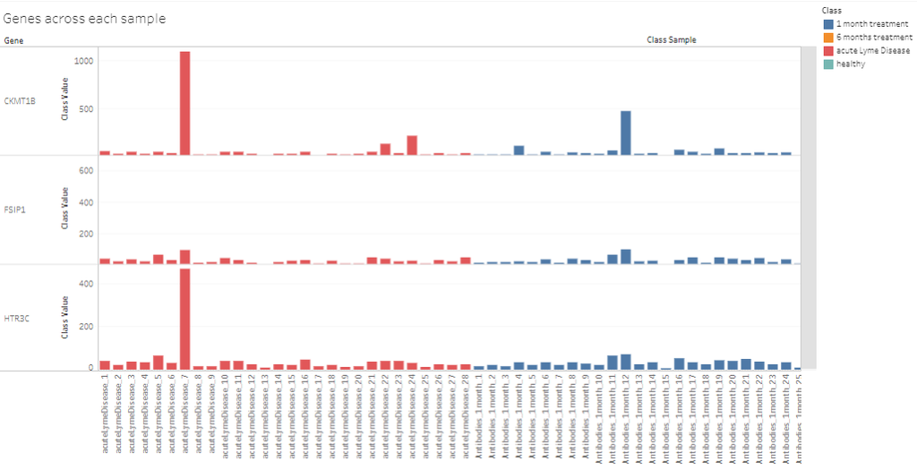

FSIP1, CKMT1B, and HTR3C spread across all samples

Figure 9: I added the sample chart to see the groups of individual samples within each class of healthy, acute lyme disease, one month of antibiotic treatment, and six months of antibiotics treatments, after realizing, some of the genes’ fold change values are skewing the data greatly. And we can see in the above image of this chart (linked to through the image) that these samples in this set of genes that skewed our data when running some machine learning algorithms were samples: sample 7 of the acute class samples, sample 12 of the 1 month class samples, sample 10 of the 6 month class samples, and samples 1, 11, and 12 of the healthy class samples. I want to remove these samples and run some machine learning on the set, or just take the median sample values instead when deriving the fold change values.

I want to backtrack at this point and use the median values by switching to a new document to test the median, and referencing back to it in this document, with the machine learning results.

I did that work on the median sample values and dropped those six classes that seemed to skew the data, but the results weren’t better and had a best score of 42% accuracy, where here the best score was 54% accuracy so far. We still need to test the machine learning results on the original data that destandardization wasn’t made to. But to access the median sample values as fold changes and the results with the six outlier samples in the mean sample derived fold change data before getting the median derived fold changes, it is on rpubs as [part 2 of the Lyme Disease Ticks](https://rpubs.com/janisharris/lymeDiseaeGSE145974part2median6samplesDropped) document.

I took out six samples that were skewed in this set, but never tested if taking those samples out of this data would improve the classification accuracy in this data. We can do that fast with our testing and training sets. Lets use all the data of training and testing set 8.

```r
row.names(training8)
```

```
##  [1] "Antibodies_6months_5" "Antibodies_1month_2"  "Antibodies_6months_9"
##  [4] "Antibodies_1month_10" "Antibodies_1month_1"  "healthyControl_4"
##  [7] "Antibodies_6months_4" "acuteLymeDisease_19"  "Antibodies_1month_25"
## [10] "Antibodies_1month_3"  "Antibodies_1month_16" "acuteLymeDisease_21"
## [13] "healthyControl_8"     "Antibodies_1month_8"  "acuteLymeDisease_15"
## [16] "acuteLymeDisease_11"  "healthyControl_5"     "Antibodies_1month_5"
## [19] "Antibodies_1month_20" "acuteLymeDisease_12"  "Antibodies_1month_9"
## [22] "acuteLymeDisease_16"  "acuteLymeDisease_28"  "acuteLymeDisease_25"
## [25] "Antibodies_6months_7" "healthyControl_2"     "Antibodies_1month_14"
## [28] "healthyControl_1"     "acuteLymeDisease_26"  "Antibodies_1month_27"
## [31] "healthyControl_6"     "acuteLymeDisease_18"  "Antibodies_1month_19"
## [34] "healthyControl_16"    "Antibodies_1month_21" "healthyControl_15"
## [37] "healthyControl_9"     "acuteLymeDisease_17"  "healthyControl_14"
## [40] "Antibodies_1month_24" "Antibodies_1month_15" "healthyControl_17"
## [43] "Antibodies_6months_6" "acuteLymeDisease_14"  "acuteLymeDisease_20"
## [46] "Antibodies_1month_7"  "healthyControl_10"    "Antibodies_6months_8"
## [49] "acuteLymeDisease_8"   "Antibodies_6months_2" "Antibodies_1month_17"
## [52] "acuteLymeDisease_3"   "Antibodies_6months_3" "healthyControl_7"
## [55] "Antibodies_1month_23" "Antibodies_1month_18" "acuteLymeDisease_2"
## [58] "Antibodies_1month_22" "acuteLymeDisease_5"   "acuteLymeDisease_10"
```

sample 7 of the acute class samples, sample 12 of the 1 month class samples, sample 10 of the 6 month class samples, and samples 1, 11, and 12 of the healthy class samples.

Check back for machine learning on the original data.

```r
skewSamples <- c('Antibodies_6months_10','Antibodies_1month_12','acuteLymeDisease_7',
                 'healthyControl_1','healthyControl_11','healthyControl_12')
```

```r
sort(row.names(training8))
```

```
##  [1] "acuteLymeDisease_10"  "acuteLymeDisease_11"  "acuteLymeDisease_12"
##  [4] "acuteLymeDisease_14"  "acuteLymeDisease_15"  "acuteLymeDisease_16"
##  [7] "acuteLymeDisease_17"  "acuteLymeDisease_18"  "acuteLymeDisease_19"
## [10] "acuteLymeDisease_2"   "acuteLymeDisease_20"  "acuteLymeDisease_21"
## [13] "acuteLymeDisease_25"  "acuteLymeDisease_26"  "acuteLymeDisease_28"
## [16] "acuteLymeDisease_3"   "acuteLymeDisease_5"   "acuteLymeDisease_8"
## [19] "Antibodies_1month_1"  "Antibodies_1month_10" "Antibodies_1month_14"
## [22] "Antibodies_1month_15" "Antibodies_1month_16" "Antibodies_1month_17"
## [25] "Antibodies_1month_18" "Antibodies_1month_19" "Antibodies_1month_2"
## [28] "Antibodies_1month_20" "Antibodies_1month_21" "Antibodies_1month_22"
## [31] "Antibodies_1month_23" "Antibodies_1month_24" "Antibodies_1month_25"
## [34] "Antibodies_1month_27" "Antibodies_1month_3"  "Antibodies_1month_5"
## [37] "Antibodies_1month_7"  "Antibodies_1month_8"  "Antibodies_1month_9"
## [40] "Antibodies_6months_2" "Antibodies_6months_3" "Antibodies_6months_4"
## [43] "Antibodies_6months_5" "Antibodies_6months_6" "Antibodies_6months_7"
## [46] "Antibodies_6months_8" "Antibodies_6months_9" "healthyControl_1"
## [49] "healthyControl_10"    "healthyControl_14"    "healthyControl_15"
## [52] "healthyControl_16"    "healthyControl_17"    "healthyControl_2"
## [55] "healthyControl_4"     "healthyControl_5"     "healthyControl_6"
## [58] "healthyControl_7"     "healthyControl_8"     "healthyControl_9"
```

```r
sort(skewSamples)
```

```
## [1] "acuteLymeDisease_7"    "Antibodies_1month_12"  "Antibodies_6months_10"
## [4] "healthyControl_1"      "healthyControl_11"     "healthyControl_12"
```

```r
skewSamples %in% row.names(training8)
```

```
## [1] FALSE FALSE FALSE  TRUE FALSE FALSE
```

```r
skewSamples %in% row.names(testing8)
```

```
## [1]  TRUE  TRUE  TRUE FALSE  TRUE  TRUE
```

```r
dim(training8);dim(testing8)
```

```
## [1] 60 44
```

```
## [1] 26 44
```

```r
training8b <- subset(training8,!(row.names(training8) %in% skewSamples))
testing8b <- subset(testing8, !(row.names(testing8) %in% skewSamples))
```

```r
skewSamples %in% row.names(training8b)
```

```
## [1] FALSE FALSE FALSE FALSE FALSE FALSE
```

```r
skewSamples %in% row.names(testing8b)
```

```
## [1] FALSE FALSE FALSE FALSE FALSE FALSE
```

```r
dim(training8b);dim(testing8b)
```

```
## [1] 59 44
```

```
## [1] 21 44
```

Now, we can see if there is an improvement in accuracy in machine learning prediction. Training/Testing 1:

```r
set.seed(589647)
rfMod8b <- train(class~., method='rf',
               na.action=na.pass,
               data=(training8b),  preProc = c("center", "scale","medianImpute"),
               trControl=trainControl(method='oob'), number=5)
```

```r
predRF8b <- predict(rfMod8b, testing8b)

predDF8b <- data.frame(predRF8b, type=testing8b$class)
predDF8b
```

```
##    predRF8b     type
## 1   healthy  healthy
## 2   healthy  healthy
## 3   healthy  healthy
## 4     acute  healthy
## 5   healthy  healthy
## 6   1 month  healthy
## 7     acute    acute
## 8   1 month    acute
## 9   1 month    acute
## 10  1 month    acute
## 11  1 month    acute
## 12    acute    acute
## 13  1 month    acute
## 14 6 months    acute
## 15  healthy    acute
## 16  1 month  1 month
## 17    acute  1 month
## 18    acute  1 month
## 19  1 month  1 month
## 20  1 month  1 month
## 21 6 months 6 months
```

```r
pra8b <- precisionRecallAccuracy(predDF8b)
```

```
## accuracy is:  47.6190476190476 %
```

```r
pra8b
```

```
##      class         precision            recall          accuracy
## 1  healthy               0.8 0.666666666666667 0.857142857142857
## 2    acute               0.4 0.222222222222222 0.523809523809524
## 3  1 month 0.333333333333333               0.6 0.619047619047619
## 4 6 months               0.5                 1 0.952380952380952
```

```r
train8b <- training8b %>% group_by(class) %>% count(class)
test8b <- testing8b %>% group_by(class) %>% count(class)
```

```r
train8b
```

```
## # A tibble: 4 x 2
## # Groups:   class [4]
##   class        n
##   <fct>    <int>
## 1 1 month     21
## 2 6 months     8
## 3 acute       18
## 4 healthy     12
```

```r
test8b
```

```
## # A tibble: 4 x 2
## # Groups:   class [4]
##   class        n
##   <fct>    <int>
## 1 1 month      5
## 2 6 months     1
## 3 acute        9
## 4 healthy      6
```

Lets first try training the data on all 86 of the samples except for 1 in each class, then use that 1 sample from each class in the testing set. To select which one to include from each class, lets only keep the one closest to the mean of their class. But we’ll use the mean of all the samples in each class.

```r
all <- rbind(testing8,training8)
dim(all)
```

```
## [1] 86 44
```